# FIA NLS Models: Biomass Growth vs. Stand Age – Data Subsets

JAH

2023-04-25

# Background

This analysis document compliments **FIA NLS Models: Biomass Growth vs. Stand Age**. All of the background information from that document applies to these analyses, which are extensions to them. The difference between that document and this analysis is the use of different data subsets.

Here, we fit the models using: 1) a temporally-balanced dataset, where we take the first and most-recent plot record for all plots in the dataset, 2) a temporally-balanced dataset (same as #1), but which excludes plot locations which have experienced harvest (at any point over the study interval 2000-2022)

Below the model fitting procedure is implemented by ecoprovince:

# Temporally-balancing the biomass growth data set

Lets look at some quick attributes of the dataset

- The data set has 115221 observations, comprised of 58079 plots.
- The frequency of growth measurements among plots is as follows (n=1 through 5): 25558, 13784, 12967, 5656, 114.
- Thus 55.99% of plots have at least two growth measurements.

# Analysis 1: Temporally-balanced analysis

## 211 - Northeastern Mixed Forest

### model selection 1

```
## Analysis of Variance Table
##
## Model 1: G_MassBal_MgHaYr ~ (1 + (MEASTIME_avg - 1990) * tau/100) * (a + b * exp(-((log(STDAGE_t1/c))/d)^2))
## Model 2: G_MassBal_MgHaYr ~ (1 + (MEASTIME_avg - 1990) * tau/100) * (1 - alpha * B_L_prop) * (a + b * exp(-((log(STDAGE_t1/c))/d)^2))
##   Res.Df Res.Sum Sq Df Sum Sq F value    Pr(>F)
## 1   4826     1878.4
## 2   4791     1374.5 35 503.91  50.185 < 2.2e-16 ***
## ---
## Signif. codes:  0 '***' 0.001 '**' 0.01 '*' 0.05 '.' 0.1 ' ' 1
##   model      AIC
## 1     1 20213.00
## 2     2 18611.61
```

```
##
## Formula: G_MassBal_MgHaYr ~ (1 + (MEASTIME_avg - 1990) * tau/100) * (1 -
##     alpha * B_L_prop) * (a + b * exp(-((log(STDAGE_t1/c))/d)^2))
##
## Parameters:
##       Estimate Std. Error t value Pr(>|t|)
## tau    0.26186    0.18087   1.448   0.1477
## alpha  0.64689    0.04082  15.846   <2e-16 ***
## a      0.00000    2.51171   0.000   1.0000
## b      3.43983    2.50007   1.376   0.1689
## c     31.68380    2.54124  12.468   <2e-16 ***
## d      2.83382    1.25991   2.249   0.0245 *
## ---
## Signif. codes:  0 '***' 0.001 '**' 0.01 '*' 0.05 '.' 0.1 ' ' 1
##
## Residual standard error: 0.5356 on 4791 degrees of freedom
##
## Algorithm "port", convergence message: relative convergence (4)
##   (37 observations deleted due to missingness)
```

#### summary

- simple model: fits
- alpha model: fits

### plot residuals

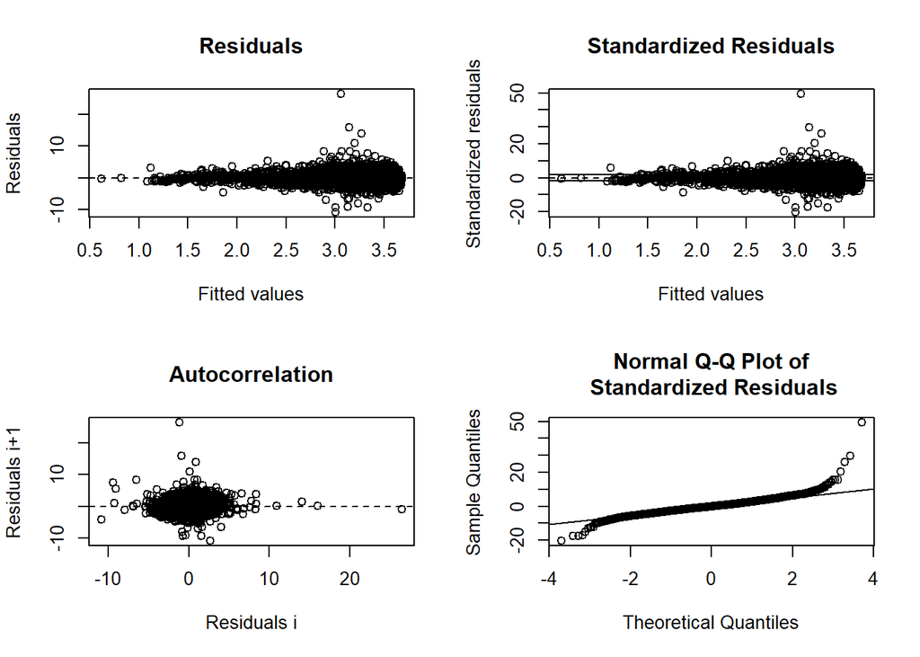

```
##
## ------
##  Shapiro-Wilk normality test
##
## data:  stdres
## W = 0.93387, p-value < 2.2e-16
##
##
## ------
```

```
##
##  Runs Test
##
## data:  as.factor(run)
## Standard Normal = -7.8042, p-value = 5.986e-15
## alternative hypothesis: two.sided
```

### predict and plot

```
## [1] "cannot plot data with prediction"
```

### plotting 2

## 212 - Laurentian Mixed Forest

### model selection 1

```
## Analysis of Variance Table
##
## Model 1: G_MassBal_MgHaYr ~ (1 + (MEASTIME_avg - 1990) * tau/100) * (a + b * exp(-((log(STDAGE_t1/c))/d)^2))
## Model 2: G_MassBal_MgHaYr ~ (1 + (MEASTIME_avg - 1990) * tau/100) * (1 - alpha * B_L_prop) * (a + b * exp(-((log(STDAGE_t1/c))/d)^2))
##   Res.Df Res.Sum Sq  Df Sum Sq F value    Pr(>F)
## 1  10034     3645.4
## 2   9749     1917.0 285 1728.4  30.843 < 2.2e-16 ***
## ---
## Signif. codes:  0 '***' 0.001 '**' 0.01 '*' 0.05 '.' 0.1 ' ' 1
##   model      AIC
## 1     1 43561.12
## 2     2 36452.31
```

```
##
## Formula: G_MassBal_MgHaYr ~ (1 + (MEASTIME_avg - 1990) * tau/100) * (1 -
##     alpha * B_L_prop) * (a + b * exp(-((log(STDAGE_t1/c))/d)^2))
##
## Parameters:
##       Estimate Std. Error t value Pr(>|t|)
## tau    1.70473    0.24596   6.931 4.45e-12 ***
## alpha  0.73161    0.02884  25.367  < 2e-16 ***
## a      0.76108    0.19188   3.966 7.35e-05 ***
## b      1.53874    0.19011   8.094 6.47e-16 ***
## c     22.00461    0.65944  33.369  < 2e-16 ***
## d      2.06444    0.20404  10.118  < 2e-16 ***
## ---
## Signif. codes:  0 '***' 0.001 '**' 0.01 '*' 0.05 '.' 0.1 ' ' 1
##
## Residual standard error: 0.4434 on 9749 degrees of freedom
##
## Algorithm "port", convergence message: relative convergence (4)
##   (3221 observations deleted due to missingness)
```

#### summary

- simple model: fits
- alpha model: fits

### plot residuals

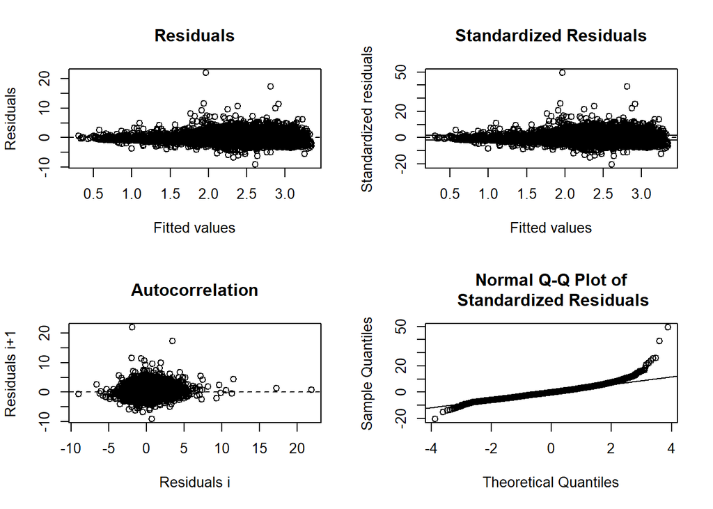

### predict and plot

```
## [1] "cannot plot data with prediction"
```

### plotting 2

## 221 - Eastern Broadleaf Forest

### model selection 1

```
## Analysis of Variance Table
##
## Model 1: G_MassBal_MgHaYr ~ (1 + (MEASTIME_avg - 1990) * tau/100) * (a + b * exp(-((log(STDAGE_t1/c))/d)^2))
## Model 2: G_MassBal_MgHaYr ~ (1 + (MEASTIME_avg - 1990) * tau/100) * (1 - alpha * B_L_prop) * (a + b * exp(-((log(STDAGE_t1/c))/d)^2))
##   Res.Df Res.Sum Sq Df Sum Sq F value    Pr(>F)
## 1   5452     2464.1
## 2   5416     2054.4 36 409.69  30.002 < 2.2e-16 ***
## ---
## Signif. codes:  0 '***' 0.001 '**' 0.01 '*' 0.05 '.' 0.1 ' ' 1
##   model      AIC
## 1     1 25174.05
## 2     2 24068.38
```

```
##
## Formula: G_MassBal_MgHaYr ~ (1 + (MEASTIME_avg - 1990) * tau/100) * (1 -
##     alpha * B_L_prop) * (a + b * exp(-((log(STDAGE_t1/c))/d)^2))
##
## Parameters:
##       Estimate Std. Error t value Pr(>|t|)
## tau    -0.5288     0.1555  -3.400 0.000679 ***
## alpha   0.7253     0.0470  15.432  < 2e-16 ***
## a       0.0000     3.6953   0.000 1.000000
## b       4.5106     3.6928   1.221 0.221968
## c      35.6964     3.4584  10.322  < 2e-16 ***
## d       3.0541     1.5363   1.988 0.046876 *
## ---
## Signif. codes:  0 '***' 0.001 '**' 0.01 '*' 0.05 '.' 0.1 ' ' 1
##
## Residual standard error: 0.6159 on 5416 degrees of freedom
##
## Algorithm "port", convergence message: relative convergence (4)
##   (40 observations deleted due to missingness)
```

#### summary

- simple model: fits
- alpha model: fits

### plot residuals

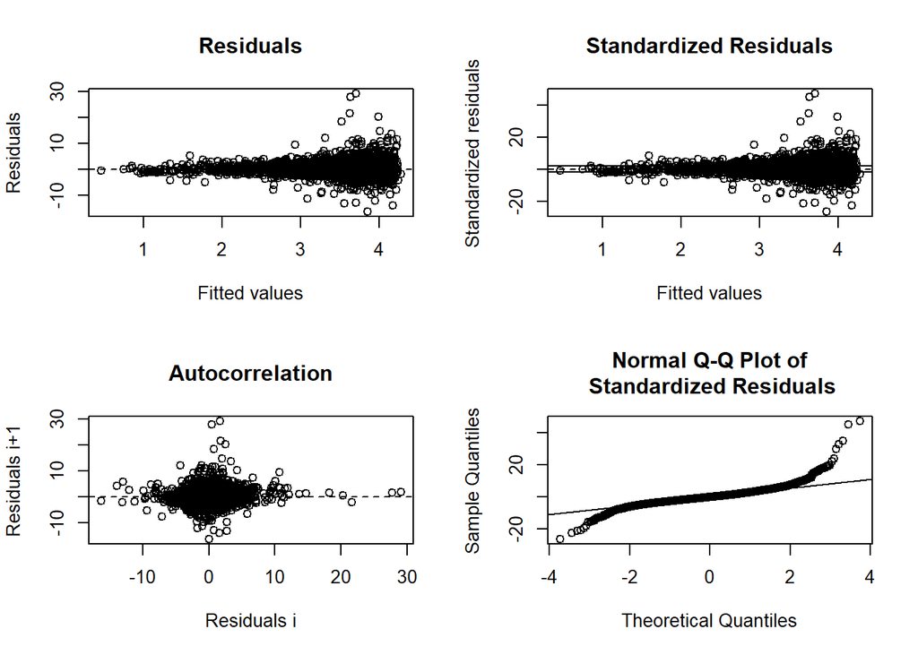

### predict and plot

```
## [1] "cannot plot data with prediction"
```

### plotting 2

## 222 - Midwest Broadleaf Forest

### model selection 1

```
## Analysis of Variance Table
##
## Model 1: G_MassBal_MgHaYr ~ (1 + (MEASTIME_avg - 1990) * tau/100) * (a + b * exp(-((log(STDAGE_t1/c))/d)^2))
## Model 2: G_MassBal_MgHaYr ~ (1 + (MEASTIME_avg - 1990) * tau/100) * (1 - alpha * B_L_prop) * (a + b * exp(-((log(STDAGE_t1/c))/d)^2))
##   Res.Df Res.Sum Sq  Df Sum Sq F value    Pr(>F)
## 1   2854    1139.35
## 2   2735     452.78 119 686.57   34.85 < 2.2e-16 ***
## ---
## Signif. codes:  0 '***' 0.001 '**' 0.01 '*' 0.05 '.' 0.1 ' ' 1
##   model      AIC
## 1     1 14497.96
## 2     2 11528.51
```

```
##
## Formula: G_MassBal_MgHaYr ~ (1 + (MEASTIME_avg - 1990) * tau/100) * (1 -
##     alpha * B_L_prop) * (a + b * exp(-((log(STDAGE_t1/c))/d)^2))
##
## Parameters:
##       Estimate Std. Error t value Pr(>|t|)
## tau    0.26774    0.30851   0.868 0.385561
## alpha  0.79228    0.05894  13.442  < 2e-16 ***
## a      1.74684    0.44991   3.883 0.000106 ***
## b      1.58842    0.44568   3.564 0.000371 ***
## c     45.82873    4.66221   9.830  < 2e-16 ***
## d      1.87974    0.46748   4.021 5.95e-05 ***
## ---
## Signif. codes:  0 '***' 0.001 '**' 0.01 '*' 0.05 '.' 0.1 ' ' 1
##
## Residual standard error: 0.4069 on 2735 degrees of freedom
##
## Algorithm "port", convergence message: relative convergence (4)
##   (813 observations deleted due to missingness)
```

#### summary

- simple model: fits
- alpha model: fits

### plot residuals

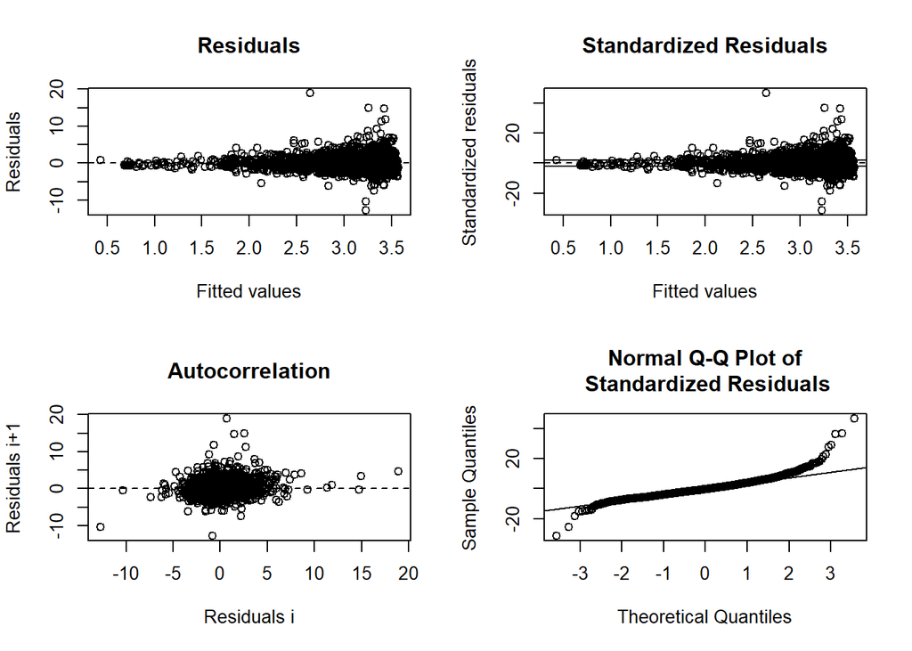

```
##
## ------
##  Shapiro-Wilk normality test
##
## data:  stdres
## W = 0.92537, p-value < 2.2e-16
##
##
## ------
```

```
##
##  Runs Test
##
## data:  as.factor(run)
## Standard Normal = -7.7786, p-value = 7.333e-15
## alternative hypothesis: two.sided
```

### predict and plot

```
## [1] "cannot plot data with prediction"
```

### plotting 2

## 223 - Central Interior Broadleaf Forest

### model selection 1

```
## Analysis of Variance Table
##
## Model 1: G_MassBal_MgHaYr ~ (1 + (MEASTIME_avg - 1990) * tau/100) * (a + b * exp(-((log(STDAGE_t1/c))/d)^2))
## Model 2: G_MassBal_MgHaYr ~ (1 + (MEASTIME_avg - 1990) * tau/100) * (1 - alpha * B_L_prop) * (a + b * exp(-((log(STDAGE_t1/c))/d)^2))
##   Res.Df Res.Sum Sq Df Sum Sq F value    Pr(>F)
## 1   5343     2129.8
## 2   5257     1293.7 86 836.14   39.51 < 2.2e-16 ***
## ---
## Signif. codes:  0 '***' 0.001 '**' 0.01 '*' 0.05 '.' 0.1 ' ' 1
##   model      AIC
## 1     1 25409.44
## 2     2 22475.46
```

```
##
## Formula: G_MassBal_MgHaYr ~ (1 + (MEASTIME_avg - 1990) * tau/100) * (1 -
##     alpha * B_L_prop) * (a + b * exp(-((log(STDAGE_t1/c))/d)^2))
##
## Parameters:
##       Estimate Std. Error t value Pr(>|t|)
## tau   -0.79712    0.13207  -6.035 1.69e-09 ***
## alpha  0.60332    0.05264  11.462  < 2e-16 ***
## a      2.77298    0.61818   4.486 7.42e-06 ***
## b      1.56332    0.59830   2.613  0.00900 **
## c     28.77781    2.74141  10.497  < 2e-16 ***
## d      1.36980    0.45143   3.034  0.00242 **
## ---
## Signif. codes:  0 '***' 0.001 '**' 0.01 '*' 0.05 '.' 0.1 ' ' 1
##
## Residual standard error: 0.4961 on 5257 degrees of freedom
##
## Algorithm "port", convergence message: relative convergence (4)
##   (1127 observations deleted due to missingness)
```

#### summary

- simple model: fits
- alpha model: fits

### plot residuals

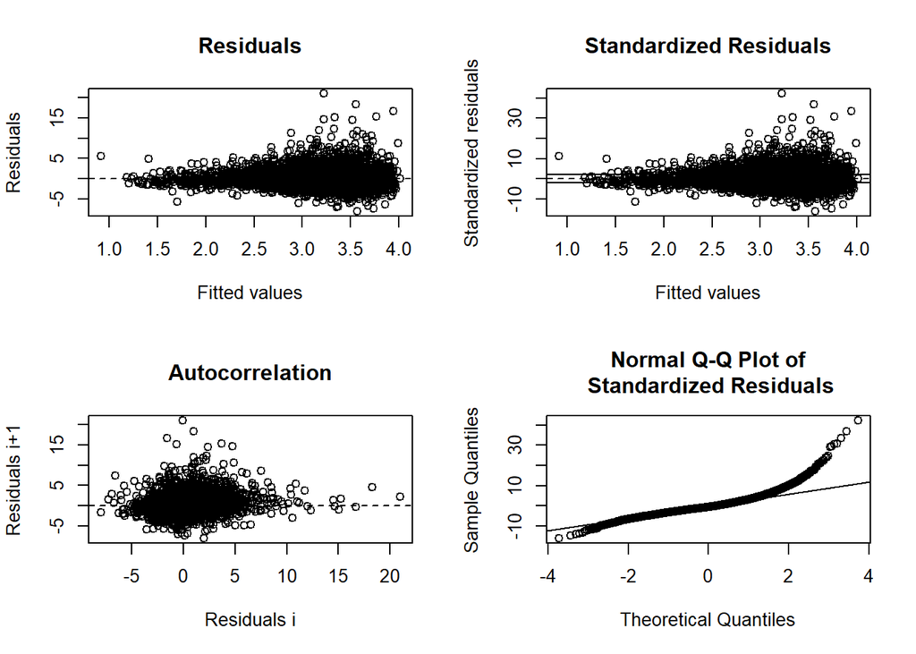

### predict and plot

```
## [1] "cannot plot data with prediction"
```

### plotting 2

## 231 - Southeastern Mixed Forest

### model selection 1

```
## Analysis of Variance Table
##
## Model 1: G_MassBal_MgHaYr ~ (1 + (MEASTIME_avg - 1990) * tau/100) * (a + b * exp(-((log(STDAGE_t1/c))/d)^2))
## Model 2: G_MassBal_MgHaYr ~ (1 + (MEASTIME_avg - 1990) * tau/100) * (1 - alpha * B_L_prop) * (a + b * exp(-((log(STDAGE_t1/c))/d)^2))
##   Res.Df Res.Sum Sq  Df Sum Sq F value    Pr(>F)
## 1   8153     4439.7
## 2   8031     3870.8 122 568.88  9.6745 < 2.2e-16 ***
## ---
## Signif. codes:  0 '***' 0.001 '**' 0.01 '*' 0.05 '.' 0.1 ' ' 1
##   model      AIC
## 1     1 42664.17
## 2     2 41126.11
```

```
##
## Formula: G_MassBal_MgHaYr ~ (1 + (MEASTIME_avg - 1990) * tau/100) * (1 -
##     alpha * B_L_prop) * (a + b * exp(-((log(STDAGE_t1/c))/d)^2))
##
## Parameters:
##       Estimate Std. Error t value Pr(>|t|)
## tau    0.85443    0.17517   4.878 1.09e-06 ***
## alpha  0.88740    0.02825  31.407  < 2e-16 ***
## a      2.32145    0.28258   8.215 2.45e-16 ***
## b      3.16038    0.27471  11.504  < 2e-16 ***
## c     18.78870    0.55514  33.845  < 2e-16 ***
## d      1.47137    0.12569  11.707  < 2e-16 ***
## ---
## Signif. codes:  0 '***' 0.001 '**' 0.01 '*' 0.05 '.' 0.1 ' ' 1
##
## Residual standard error: 0.6943 on 8031 degrees of freedom
##
## Algorithm "port", convergence message: relative convergence (4)
##   (163 observations deleted due to missingness)
```

#### summary

- simple model: fits
- alpha model: fits

### plot residuals

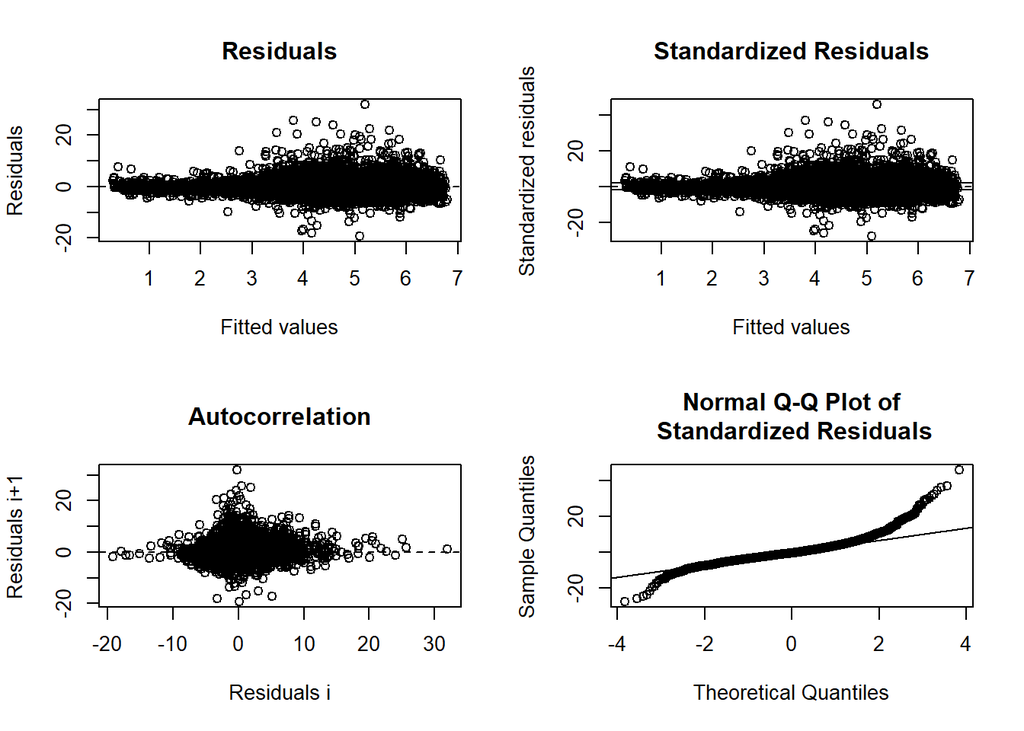

### predict and plot

```
## [1] "cannot plot data with prediction"
```

### plotting 2

## 232 - Outer Coastal Plain Mixed Forest

### model selection 1

```
## Analysis of Variance Table
##
## Model 1: G_MassBal_MgHaYr ~ (1 + (MEASTIME_avg - 1990) * tau/100) * (a + b * exp(-((log(STDAGE_t1/c))/d)^2))
## Model 2: G_MassBal_MgHaYr ~ (1 + (MEASTIME_avg - 1990) * tau/100) * (1 - alpha * B_L_prop) * (a + b * exp(-((log(STDAGE_t1/c))/d)^2))
##   Res.Df Res.Sum Sq  Df Sum Sq F value    Pr(>F)
## 1   8129     5671.1
## 2   7971     4985.8 158 685.29  6.9341 < 2.2e-16 ***
## ---
## Signif. codes:  0 '***' 0.001 '**' 0.01 '*' 0.05 '.' 0.1 ' ' 1
##   model      AIC
## 1     1 42533.94
## 2     2 40899.77
```

```
##
## Formula: G_MassBal_MgHaYr ~ (1 + (MEASTIME_avg - 1990) * tau/100) * (1 -
##     alpha * B_L_prop) * (a + b * exp(-((log(STDAGE_t1/c))/d)^2))
##
## Parameters:
##       Estimate Std. Error t value Pr(>|t|)
## tau    1.10804    0.21778   5.088  3.7e-07 ***
## alpha  0.87394    0.02882  30.324  < 2e-16 ***
## a      3.05106    0.13744  22.199  < 2e-16 ***
## b      2.00828    0.13022  15.423  < 2e-16 ***
## c     16.39313    0.62599  26.188  < 2e-16 ***
## d      0.88642    0.07029  12.610  < 2e-16 ***
## ---
## Signif. codes:  0 '***' 0.001 '**' 0.01 '*' 0.05 '.' 0.1 ' ' 1
##
## Residual standard error: 0.7909 on 7971 degrees of freedom
##
## Algorithm "port", convergence message: relative convergence (4)
##   (217 observations deleted due to missingness)
```

#### summary

- simple model: fits
- alpha model: fits

### plot residuals

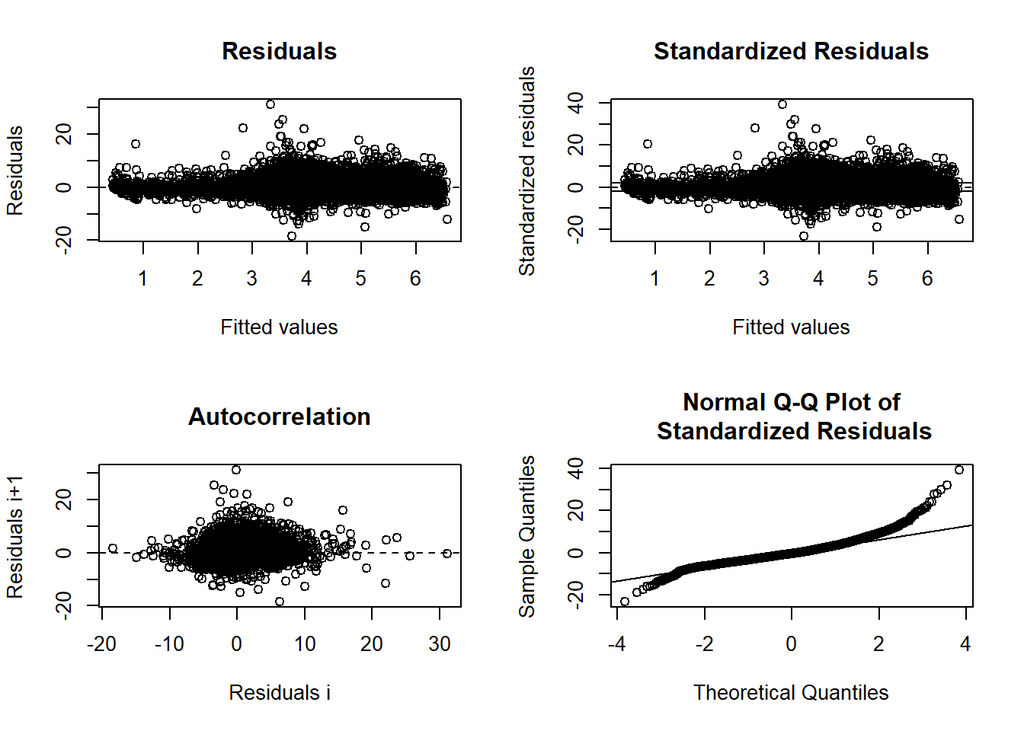

### predict and plot

```
## [1] "cannot plot data with prediction"
```

### plotting 2

## 234 - Lower Mississippi Riverine Forest

### model selection 1

```
## Analysis of Variance Table
##
## Model 1: G_MassBal_MgHaYr ~ (1 + (MEASTIME_avg - 1990) * tau/100) * (a + b * exp(-((log(STDAGE_t1/c))/d)^2))
## Model 2: G_MassBal_MgHaYr ~ (1 + (MEASTIME_avg - 1990) * tau/100) * (1 - alpha * B_L_prop) * (a + b * exp(-((log(STDAGE_t1/c))/d)^2))
##   Res.Df Res.Sum Sq Df Sum Sq F value    Pr(>F)
## 1    846     572.27
## 2    826     521.15 20 51.124  4.0515 8.132e-09 ***
## ---
## Signif. codes:  0 '***' 0.001 '**' 0.01 '*' 0.05 '.' 0.1 ' ' 1
##   model      AIC
## 1     1 4519.781
## 2     2 4373.858
```

```
##
## Formula: G_MassBal_MgHaYr ~ (1 + (MEASTIME_avg - 1990) * tau/100) * (1 -
##     alpha * B_L_prop) * (a + b * exp(-((log(STDAGE_t1/c))/d)^2))
##
## Parameters:
##       Estimate Std. Error t value Pr(>|t|)
## tau     1.4702     1.0319   1.425 0.154587
## alpha   0.8577     0.1047   8.190 9.88e-16 ***
## a       3.2558     0.5921   5.499 5.10e-08 ***
## b       1.9705     0.6409   3.075 0.002177 **
## c      18.9098     2.6824   7.050 3.79e-12 ***
## d       0.6605     0.1994   3.313 0.000964 ***
## ---
## Signif. codes:  0 '***' 0.001 '**' 0.01 '*' 0.05 '.' 0.1 ' ' 1
##
## Residual standard error: 0.7943 on 826 degrees of freedom
##
## Algorithm "port", convergence message: relative convergence (4)
##   (30 observations deleted due to missingness)
```

#### summary

- simple model: fits
- alpha model: fits

### plot residuals

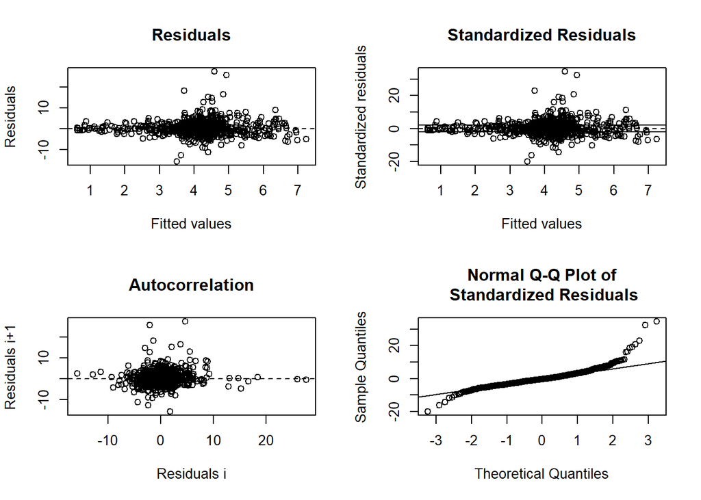

```
##
## ------
##  Shapiro-Wilk normality test
##
## data:  stdres
## W = 0.88188, p-value < 2.2e-16
##
##
## ------
```

```
##
##  Runs Test
##
## data:  as.factor(run)
## Standard Normal = -4.0363, p-value = 5.43e-05
## alternative hypothesis: two.sided
```

### predict and plot

```
## [1] "cannot plot data with prediction"
```

### plotting 2

## 242 - Pacific Lowland Mixed Forest

### model selection 1

#### summary

- simple model: does not fit
- alpha model: does not fit

### plot residuals

```
## [1] "cannot plot residuals"
```

### predict and plot

```
## [1] "cannot plot data with prediction"
```

### plotting 2

## 251 - Prairie Parkland (Temperate)

### model selection 1

```
## Analysis of Variance Table
##
## Model 1: G_MassBal_MgHaYr ~ (1 + (MEASTIME_avg - 1990) * tau/100) * (a + b * exp(-((log(STDAGE_t1/c))/d)^2))
## Model 2: G_MassBal_MgHaYr ~ (1 + (MEASTIME_avg - 1990) * tau/100) * (1 - alpha * B_L_prop) * (a + b * exp(-((log(STDAGE_t1/c))/d)^2))
##   Res.Df Res.Sum Sq Df Sum Sq F value    Pr(>F)
## 1   1038     516.93
## 2    976     194.87 62 322.06  26.017 < 2.2e-16 ***
## ---
## Signif. codes:  0 '***' 0.001 '**' 0.01 '*' 0.05 '.' 0.1 ' ' 1
##   model      AIC
## 1     1 5430.578
## 2     2 4227.322
```

```
##
## Formula: G_MassBal_MgHaYr ~ (1 + (MEASTIME_avg - 1990) * tau/100) * (1 -
##     alpha * B_L_prop) * (a + b * exp(-((log(STDAGE_t1/c))/d)^2))
##
## Parameters:
##       Estimate Std. Error t value Pr(>|t|)
## tau     0.2119     0.5979   0.354   0.7232
## alpha   0.4322     0.1502   2.877   0.0041 **
## a       0.0000    87.3440   0.000   1.0000
## b       2.9749    87.2757   0.034   0.9728
## c      14.4118    20.0600   0.718   0.4727
## d       5.6217    90.3694   0.062   0.9504
## ---
## Signif. codes:  0 '***' 0.001 '**' 0.01 '*' 0.05 '.' 0.1 ' ' 1
##
## Residual standard error: 0.4468 on 976 degrees of freedom
##
## Algorithm "port", convergence message: relative convergence (4)
##   (412 observations deleted due to missingness)
```

#### summary

- simple model: fits
- alpha model: fits

### plot residuals

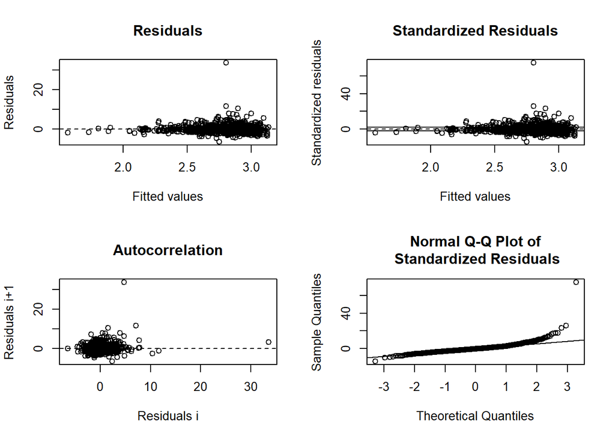

```
##
## ------
##  Shapiro-Wilk normality test
##
## data:  stdres
## W = 0.73795, p-value < 2.2e-16
##
##
## ------
```

```
##
##  Runs Test
##
## data:  as.factor(run)
## Standard Normal = -2.0562, p-value = 0.03977
## alternative hypothesis: two.sided
```

### predict and plot

```
## [1] "cannot plot data with prediction"
```

### plotting 2

## 255 - Prairie Parkland (Subtropical)

### model selection 1

```
## Analysis of Variance Table
##
## Model 1: G_MassBal_MgHaYr ~ (1 + (MEASTIME_avg - 1990) * tau/100) * (a + b * exp(-((log(STDAGE_t1/c))/d)^2))
## Model 2: G_MassBal_MgHaYr ~ (1 + (MEASTIME_avg - 1990) * tau/100) * (1 - alpha * B_L_prop) * (a + b * exp(-((log(STDAGE_t1/c))/d)^2))
##   Res.Df Res.Sum Sq Df Sum Sq F value Pr(>F)
## 1    440     887.59
## 2    416     856.04 24 31.556   0.639 0.9068
##   model      AIC
## 1     1 2424.892
## 2     2 2325.853
```

```
##
## Formula: G_MassBal_MgHaYr ~ (1 + (MEASTIME_avg - 1990) * tau/100) * (1 -
##     alpha * B_L_prop) * (a + b * exp(-((log(STDAGE_t1/c))/d)^2))
##
## Parameters:
##       Estimate Std. Error t value Pr(>|t|)
## tau     2.0773     2.8209   0.736 0.461907
## alpha   0.5298     0.3225   1.643 0.101145
## a       0.7449     0.4168   1.787 0.074626 .
## b       2.1824     1.0219   2.136 0.033300 *
## c      25.0921     2.9987   8.368 9.01e-16 ***
## d       0.7825     0.2351   3.328 0.000952 ***
## ---
## Signif. codes:  0 '***' 0.001 '**' 0.01 '*' 0.05 '.' 0.1 ' ' 1
##
## Residual standard error: 1.434 on 416 degrees of freedom
##
## Algorithm "port", convergence message: relative convergence (4)
##   (24 observations deleted due to missingness)
```

#### summary

- simple model: fits
- alpha model: fits

### plot residuals

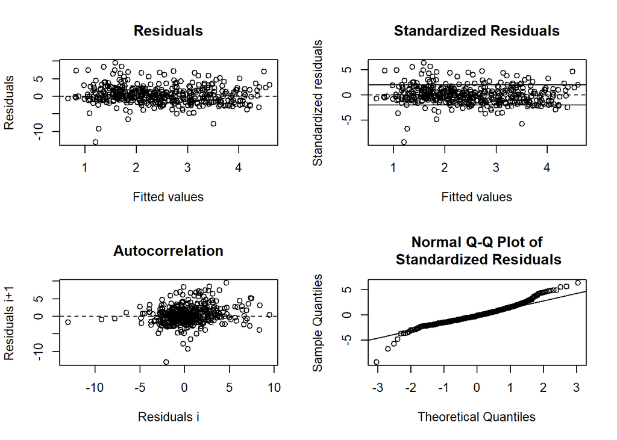

```
##
## ------
##  Shapiro-Wilk normality test
##
## data:  stdres
## W = 0.95676, p-value = 8.57e-10
##
##
## ------
```

```
##
##  Runs Test
##
## data:  as.factor(run)
## Standard Normal = -2.7109, p-value = 0.00671
## alternative hypothesis: two.sided
```

### predict and plot

```
## [1] "cannot plot data with prediction"
```

### plotting 2

## 261 - California Coastal Chaparral Forest and Shrub

### model selection 1

#### summary

- simple model: does not fit
- alpha model: does not fit

### plot residuals

```
## [1] "cannot plot residuals"
```

### predict and plot

```
## [1] "cannot plot data with prediction"
```

### plotting 2

## 262 - California Dry Steppe

### model selection 1

#### summary

- simple model: does not fit
- alpha model: does not fit

### plot residuals

```
## [1] "cannot plot residuals"
```

### predict and plot

```
## [1] "cannot plot data with prediction"
```

### plotting 2

## 263 - California Coastal Steppe - Mixed Forest and Redwood Forest

### model selection 1

#### summary

- simple model: does not fit
- alpha model: does not fit

### plot residuals

```
## [1] "cannot plot residuals"
```

### predict and plot

```
## [1] "cannot plot data with prediction"
```

### plotting 2

## 313 - Colorado Plateau Semi-Desert

### model selection 1

#### summary

- simple model: does not fit
- alpha model: does not fit

### plot residuals

```
## [1] "cannot plot residuals"
```

### predict and plot

```
## [1] "cannot plot data with prediction"
```

### plotting 2

## 315 - Southwest Plateau and Plains Dry Steppe and Shrub

### model selection 1

#### summary

- simple model: does not fit
- alpha model: does not fit

### plot residuals

```
## [1] "cannot plot residuals"
```

### predict and plot

```
## [1] "cannot plot data with prediction"
```

### plotting 2

## 321 - Chihuahuan Semi-Desert

### model selection 1

#### summary

- simple model: does not fit
- alpha model: does not fit

### plot residuals

```
## [1] "cannot plot residuals"
```

### predict and plot

```
## [1] "cannot plot data with prediction"
```

### plotting 2

## 322 - American Semidesert and Desert

### model selection 1

#### summary

- simple model: does not fit
- alpha model: does not fit

### plot residuals

```
## [1] "cannot plot residuals"
```

### predict and plot

```
## [1] "cannot plot data with prediction"
```

### plotting 2

## 331 - Great Plains/Palouse Dry Steppe

### model selection 1

#### summary

- simple model: does not fit
- alpha model: does not fit

### plot residuals

```
## [1] "cannot plot residuals"
```

### predict and plot

```
## [1] "cannot plot data with prediction"
```

### plotting 2

## 332 - Great Plains Steppe

### model selection 1

#### summary

- simple model: does not fit
- alpha model: does not fit

### plot residuals

```
## [1] "cannot plot residuals"
```

### predict and plot

```
## [1] "cannot plot data with prediction"
```

### plotting 2

## 341 - Intermountain Semi-desert & Desert

### model selection 1

#### summary

- simple model: does not fit
- alpha model: does not fit

### plot residuals

```
## [1] "cannot plot residuals"
```

### predict and plot

```
## [1] "cannot plot data with prediction"
```

### plotting 2

## 342 - Intermountain Semi-Desert

### model selection 1

#### summary

- simple model: does not fit
- alpha model: does not fit

### plot residuals

```
## [1] "cannot plot residuals"
```

### predict and plot

```
## [1] "cannot plot data with prediction"
```

### plotting 2

## 411 - Everglades

### model selection 1

#### summary

- simple model: does not fit
- alpha model: does not fit

### plot residuals

```
## [1] "cannot plot residuals"
```

### predict and plot

```
## [1] "cannot plot data with prediction"
```

### plotting 2

## M211 - Adirondack-New England Mixed forest - Coniferous Forest - Alpine Meadow

### model selection 1

```
## Analysis of Variance Table
##
## Model 1: G_MassBal_MgHaYr ~ (1 + (MEASTIME_avg - 1990) * tau/100) * (a + b * exp(-((log(STDAGE_t1/c))/d)^2))
## Model 2: G_MassBal_MgHaYr ~ (1 + (MEASTIME_avg - 1990) * tau/100) * (1 - alpha * B_L_prop) * (a + b * exp(-((log(STDAGE_t1/c))/d)^2))
##   Res.Df Res.Sum Sq Df Sum Sq F value    Pr(>F)
## 1   5098     1399.0
## 2   5083     1313.7 15 85.242  21.988 < 2.2e-16 ***
## ---
## Signif. codes:  0 '***' 0.001 '**' 0.01 '*' 0.05 '.' 0.1 ' ' 1
##   model      AIC
## 1     1 19322.30
## 2     2 18966.14
```

```
##
## Formula: G_MassBal_MgHaYr ~ (1 + (MEASTIME_avg - 1990) * tau/100) * (1 -
##     alpha * B_L_prop) * (a + b * exp(-((log(STDAGE_t1/c))/d)^2))
##
## Parameters:
##       Estimate Std. Error t value Pr(>|t|)
## tau    1.04300    0.23979   4.350 1.39e-05 ***
## alpha  0.63548    0.03458  18.376  < 2e-16 ***
## a      1.93822    0.53830   3.601 0.000321 ***
## b      1.05210    0.51152   2.057 0.039757 *
## c     31.84635    2.61486  12.179  < 2e-16 ***
## d      1.53777    0.58827   2.614 0.008974 **
## ---
## Signif. codes:  0 '***' 0.001 '**' 0.01 '*' 0.05 '.' 0.1 ' ' 1
##
## Residual standard error: 0.5084 on 5083 degrees of freedom
##
## Algorithm "port", convergence message: relative convergence (4)
##   (15 observations deleted due to missingness)
```

#### summary

- simple model: fits
- alpha model: fits

### plot residuals

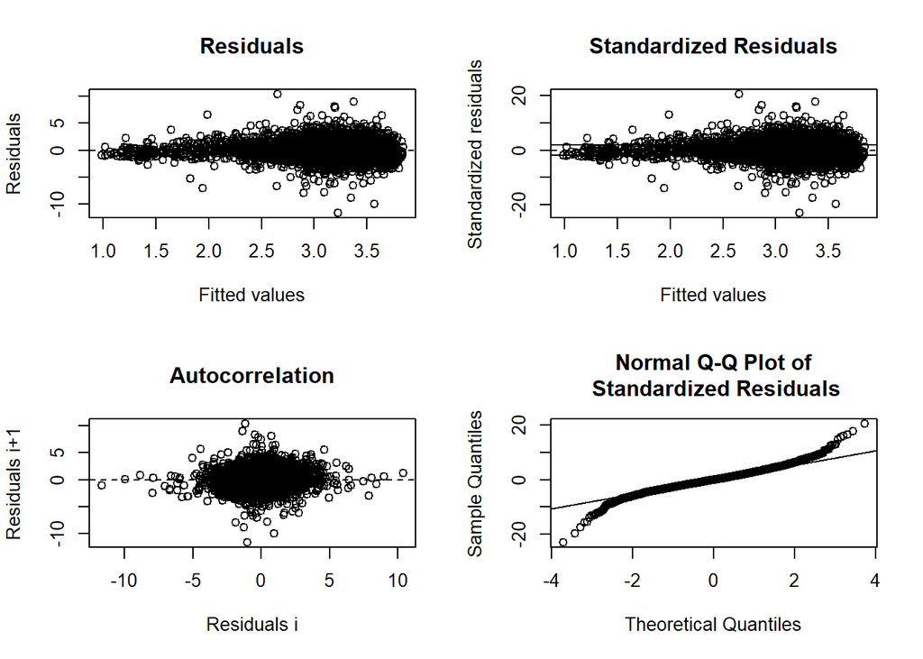

### predict and plot

```
## [1] "cannot plot data with prediction"
```

```
## Analysis of Variance Table
##
## Model 1: G_MassBal_MgHaYr ~ (1 + (MEASTIME_avg - 1990) * tau/100) * (a + b * exp(-((log(STDAGE_t1/c))/d)^2))
## Model 2: G_MassBal_MgHaYr ~ (1 + (MEASTIME_avg - 1990) * tau/100) * (1 - alpha * B_L_prop) * (a + b * exp(-((log(STDAGE_t1/c))/d)^2))
##   Res.Df Res.Sum Sq Df Sum Sq F value    Pr(>F)
## 1   5256     3349.7
## 2   5228     3020.7 28 329.07  20.341 < 2.2e-16 ***
## ---
## Signif. codes:  0 '***' 0.001 '**' 0.01 '*' 0.05 '.' 0.1 ' ' 1
##   model      AIC
## 1     1 26437.59
## 2     2 25791.14
```

```
##
## Formula: G_MassBal_MgHaYr ~ (1 + (MEASTIME_avg - 1990) * tau/100) * (1 -
##     alpha * B_L_prop) * (a + b * exp(-((log(STDAGE_t1/c))/d)^2))
##
## Parameters:
##       Estimate Std. Error t value Pr(>|t|)
## tau    0.25684    0.22067   1.164 0.244513
## alpha  0.84830    0.07203  11.778  < 2e-16 ***
## a      2.57348    0.54972   4.681 2.92e-06 ***
## b      1.94772    0.50170   3.882 0.000105 ***
## c     28.68019    2.45955  11.661  < 2e-16 ***
## d      1.30323    0.34465   3.781 0.000158 ***
## ---
## Signif. codes:  0 '***' 0.001 '**' 0.01 '*' 0.05 '.' 0.1 ' ' 1
##
## Residual standard error: 0.7601 on 5228 degrees of freedom
##
## Algorithm "port", convergence message: relative convergence (4)
##   (28 observations deleted due to missingness)
```

#### summary

- simple model: fits
- alpha model: fits

### plot residuals

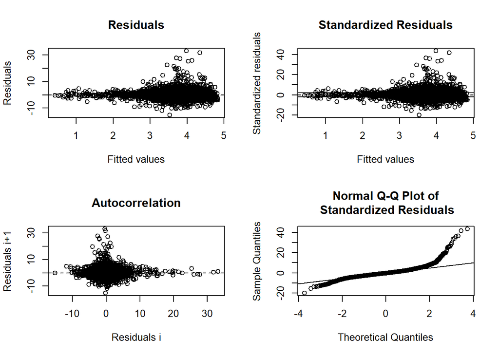

### predict and plot

```
## [1] "cannot plot data with prediction"
```

### plotting 2

## M223 - Ozark Broadleaf Forest Meadow

### model selection 1

```
## Analysis of Variance Table
##
## Model 1: G_MassBal_MgHaYr ~ (1 + (MEASTIME_avg - 1990) * tau/100) * (a + b * exp(-((log(STDAGE_t1/c))/d)^2))
## Model 2: G_MassBal_MgHaYr ~ (1 + (MEASTIME_avg - 1990) * tau/100) * (1 - alpha * B_L_prop) * (a + b * exp(-((log(STDAGE_t1/c))/d)^2))
##   Res.Df Res.Sum Sq Df Sum Sq F value    Pr(>F)
## 1    598     363.57
## 2    594     349.87  4 13.692  5.8112 0.0001363 ***
## ---
## Signif. codes:  0 '***' 0.001 '**' 0.01 '*' 0.05 '.' 0.1 ' ' 1
##   model      AIC
## 1     1 2558.886
## 2     2 2528.660
```

```
##
## Formula: G_MassBal_MgHaYr ~ (1 + (MEASTIME_avg - 1990) * tau/100) * (1 -
##     alpha * B_L_prop) * (a + b * exp(-((log(STDAGE_t1/c))/d)^2))
##
## Parameters:
##       Estimate Std. Error t value Pr(>|t|)
## tau     3.2919     1.7869   1.842 0.065941 .
## alpha   0.9748     0.2043   4.772 2.30e-06 ***
## a       1.4897     0.3536   4.213 2.91e-05 ***
## b       1.2135     0.4580   2.649 0.008280 **
## c      30.7923     2.7314  11.273  < 2e-16 ***
## d       0.4089     0.1089   3.754 0.000191 ***
## ---
## Signif. codes:  0 '***' 0.001 '**' 0.01 '*' 0.05 '.' 0.1 ' ' 1
##
## Residual standard error: 0.7675 on 594 degrees of freedom
##
## Algorithm "port", convergence message: relative convergence (4)
##   (4 observations deleted due to missingness)
```

#### summary

- simple model: fits
- alpha model: fits

### plot residuals

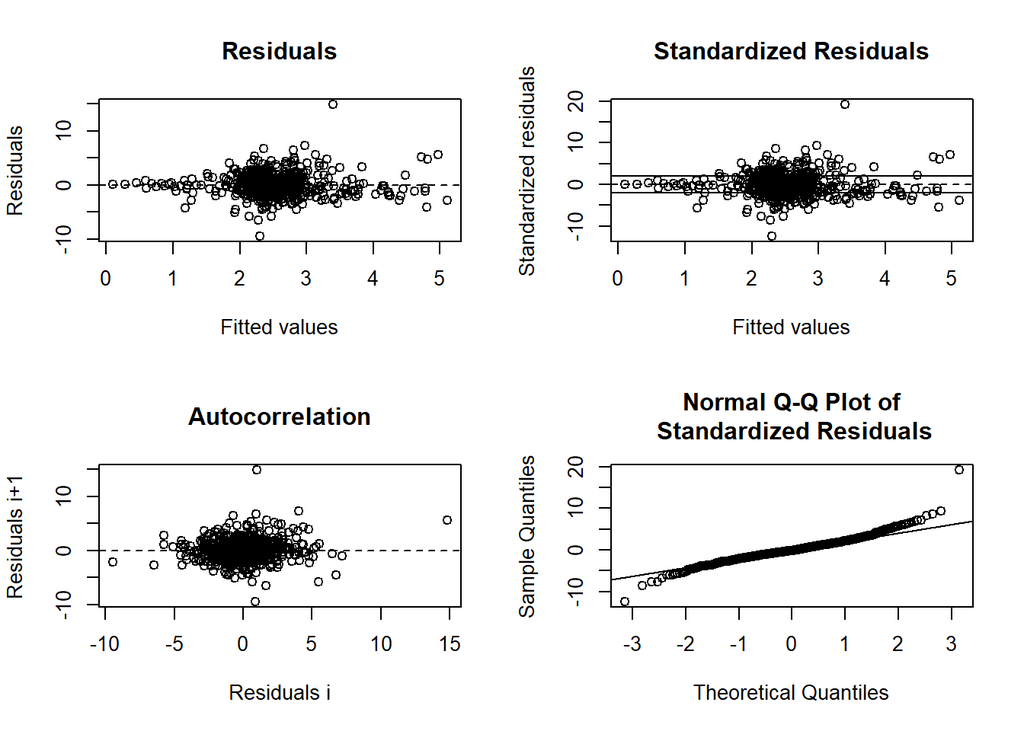

```
##
## ------
##  Shapiro-Wilk normality test
##
## data:  stdres
## W = 0.94973, p-value = 2.048e-13
##
##
## ------
```

```
##
##  Runs Test
##
## data:  as.factor(run)
## Standard Normal = -1.9525, p-value = 0.05088
## alternative hypothesis: two.sided
```

### predict and plot

```
## [1] "cannot plot data with prediction"
```

### plotting 2

## M231 - Ouachita Mixed Forest

### model selection 1

```
## Error in nls(fg2_2, data = G_M231, start = c(tau = tau.start, alpha = alpha.start,  :
##   Convergence failure: iteration limit reached without convergence (10)
##   model      AIC
## 1     1 2897.814
## 2     2       NA
```

```
##
## Formula: G_MassBal_MgHaYr ~ (1 + (MEASTIME_avg - 1990) * tau/100) * (a +
##     b * exp(-((log(STDAGE_t1/c))/d)^2))
##
## Parameters:
##     Estimate Std. Error t value Pr(>|t|)
## tau   5.0000     2.9393   1.701  0.08939 .
## a     1.2478     0.3874   3.221  0.00134 **
## b     1.6161     4.2425   0.381  0.70337
## c     4.0019    12.1961   0.328  0.74292
## d     1.0428     1.5981   0.653  0.51426
## ---
## Signif. codes:  0 '***' 0.001 '**' 0.01 '*' 0.05 '.' 0.1 ' ' 1
##
## Residual standard error: 0.7503 on 672 degrees of freedom
##
## Algorithm "port", convergence message: relative convergence (4)
##   (1 observation deleted due to missingness)
```

#### summary

- simple model: fits
- alpha model: does not fit

### plot residuals

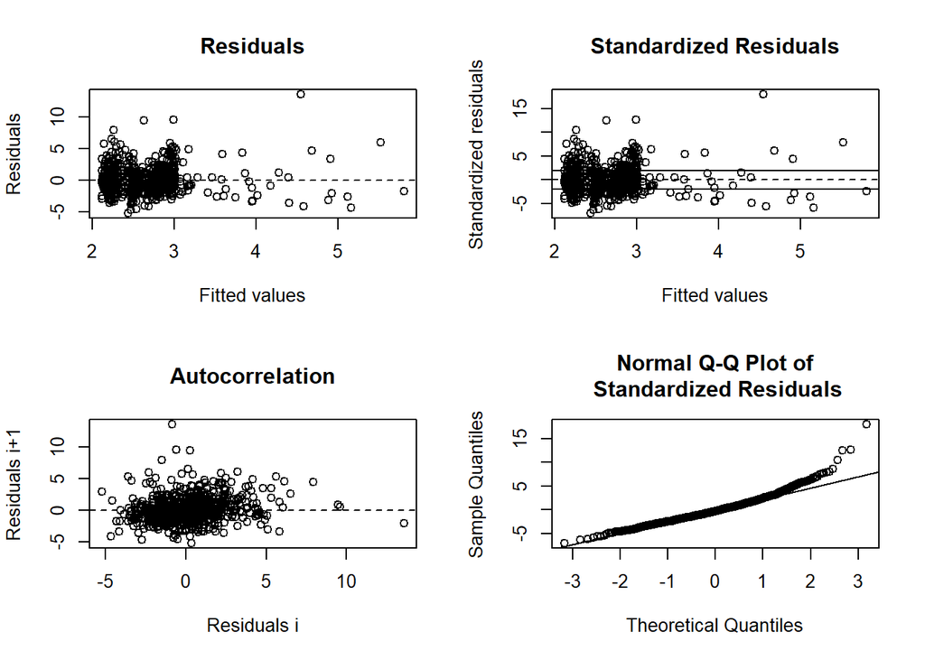

```
##
## ------
##  Shapiro-Wilk normality test
##
## data:  stdres
## W = 0.94881, p-value = 1.471e-14
##
##
## ------
```

```
##
##  Runs Test
##
## data:  as.factor(run)
## Standard Normal = -4.7655, p-value = 1.884e-06
## alternative hypothesis: two.sided
```

### predict and plot

```
## [1] "cannot plot data with prediction"
```

### plotting 2

## M242 - Cascade Mixed Forest

### model selection 1

```
## Error in nls(fg2_1, data = G_M242, start = c(tau = tau.start, a = a.start,  :
##   Convergence failure: iteration limit reached without convergence (10)
## Error in nls(fg2_2, data = G_M242, start = c(tau = tau.start, alpha = alpha.start,  :
##   Convergence failure: iteration limit reached without convergence (10)
##   model AIC
## 1     1  NA
## 2     2  NA
```

[output not shown]

#### summary

- simple model: does not fit
- alpha model: does not fit

### plot residuals

```
## [1] "cannot plot residuals"
```

### predict and plot

```
## [1] "cannot plot data with prediction"
```

### plotting 2

## M261 - Sierran Steppe - Mixed Forest - Coniferous Forest - Alpine Meadow

### model selection 1

```
## Analysis of Variance Table
##
## Model 1: G_MassBal_MgHaYr ~ (1 + (MEASTIME_avg - 1990) * tau/100) * (a + b * exp(-((log(STDAGE_t1/c))/d)^2))
## Model 2: G_MassBal_MgHaYr ~ (1 + (MEASTIME_avg - 1990) * tau/100) * (1 - alpha * B_L_prop) * (a + b * exp(-((log(STDAGE_t1/c))/d)^2))
##   Res.Df Res.Sum Sq Df   Sum Sq F value  Pr(>F)
## 1    164     4.2484
## 2    163     4.1547  1 0.093752  3.6782 0.05688 .
## ---
## Signif. codes:  0 '***' 0.001 '**' 0.01 '*' 0.05 '.' 0.1 ' ' 1
##   model      AIC
## 1     1 651.0310
## 2     2 649.2599
```

```
##
## Formula: G_MassBal_MgHaYr ~ (1 + (MEASTIME_avg - 1990) * tau/100) * (1 -
##     alpha * B_L_prop) * (a + b * exp(-((log(STDAGE_t1/c))/d)^2))
##
## Parameters:
##       Estimate Std. Error t value Pr(>|t|)
## tau    -2.4240     1.1741  -2.065   0.0405 *
## alpha   0.6567     0.2868   2.290   0.0233 *
## a       2.2978     1.4973   1.535   0.1268
## b       6.0186     3.7246   1.616   0.1080
## c      43.6509     5.4760   7.971 2.59e-13 ***
## d       0.6480     0.1545   4.194 4.49e-05 ***
## ---
## Signif. codes:  0 '***' 0.001 '**' 0.01 '*' 0.05 '.' 0.1 ' ' 1
##
## Residual standard error: 0.1597 on 163 degrees of freedom
##
## Algorithm "port", convergence message: relative convergence (4)
##   (171 observations deleted due to missingness)
```

#### summary

- simple model: fits
- alpha model: fits

### plot residuals

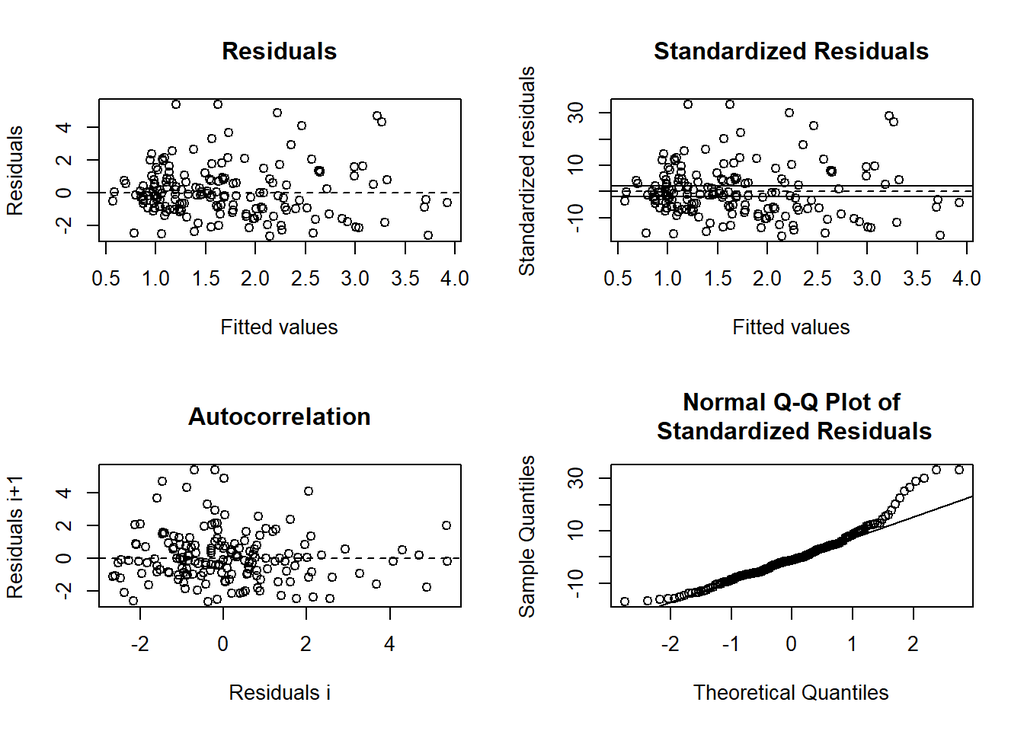

```
##
## ------
##  Shapiro-Wilk normality test
##
## data:  stdres
## W = 0.94352, p-value = 2.967e-06
##
##
## ------
```

```
##
##  Runs Test
##
## data:  as.factor(run)
## Standard Normal = 0.84398, p-value = 0.3987
## alternative hypothesis: two.sided
```

### predict and plot

```
## [1] "cannot plot data with prediction"
```

### plotting 2

## M262 - Califormia Coastal Range = Coniferous Forest - Open woodland Shrub Meadow

### model selection 1

#### summary

- simple model: does not fit
- alpha model: does not fit

### plot residuals

```
## [1] "cannot plot residuals"
```

### predict and plot

```
## [1] "cannot plot data with prediction"
```

### plotting 2

## M313 - Arizona-New Mexico Mountains Semi-Desert - Open Woodland - Coniferous Forest - Alpine Meadow

### model selection 1

[output not shown]

[output not shown]

#### summary

- simple model: does not fit
- alpha model: does not fit

### plot residuals

```
## [1] "cannot plot residuals"
```

### predict and plot

```
## [1] "cannot plot data with prediction"
```

### plotting 2

## M331 - Southern Rocky Mountain Steppe - Open Woodland - Coniferous Forest - Alpine Meadow

### model selection 1

[output not shown]

[output not shown]

#### summary

- simple model: does not fit
- alpha model: does not fit

### plot residuals

```
## [1] "cannot plot residuals"
```

### predict and plot

```
## [1] "cannot plot data with prediction"
```

### plotting 2

## M332 - Middle Rocky Mountain Steppe - Coniferous Forest - Alpine Meadow

### model selection 1

#### summary

- simple model: does not fit
- alpha model: does not fit

### plot residuals

```
## [1] "cannot plot residuals"
```

### predict and plot

```
## [1] "cannot plot data with prediction"
```

### plotting 2

## M333 - Northern Rocky Mountain Steppe - Coniferous Forest - Alpine Meadow

### model selection 1

#### summary

- simple model: does not fit
- alpha model: does not fit

### plot residuals

```
## [1] "cannot plot residuals"
```

### predict and plot

```
## [1] "cannot plot data with prediction"
```

### plotting 2

## M334 - Black Hills Coniferous Forest

### model selection 1

```
## Analysis of Variance Table
##
## Model 1: G_MassBal_MgHaYr ~ (1 + (MEASTIME_avg - 1990) * tau/100) * (a + b * exp(-((log(STDAGE_t1/c))/d)^2))
## Model 2: G_MassBal_MgHaYr ~ (1 + (MEASTIME_avg - 1990) * tau/100) * (1 - alpha * B_L_prop) * (a + b * exp(-((log(STDAGE_t1/c))/d)^2))
##   Res.Df Res.Sum Sq Df Sum Sq F value    Pr(>F)
## 1    218     35.122
## 2    212     21.490  6 13.632  22.413 < 2.2e-16 ***
## ---
## Signif. codes:  0 '***' 0.001 '**' 0.01 '*' 0.05 '.' 0.1 ' ' 1
##   model      AIC
## 1     1 891.5661
## 2     2 772.9166
```

```
##
## Formula: G_MassBal_MgHaYr ~ (1 + (MEASTIME_avg - 1990) * tau/100) * (1 -
##     alpha * B_L_prop) * (a + b * exp(-((log(STDAGE_t1/c))/d)^2))
##
## Parameters:
##       Estimate Std. Error t value Pr(>|t|)
## tau    -0.5187     1.2672  -0.409  0.68272
## alpha   0.8206     0.2082   3.942  0.00011 ***
## a       0.0000     4.6483   0.000  1.00000
## b       1.9247     4.6286   0.416  0.67796
## c      59.0222     9.3457   6.315 1.56e-09 ***
## d       1.3851     2.2588   0.613  0.54041
## ---
## Signif. codes:  0 '***' 0.001 '**' 0.01 '*' 0.05 '.' 0.1 ' ' 1
##
## Residual standard error: 0.3184 on 212 degrees of freedom
##
## Algorithm "port", convergence message: relative convergence (4)
##   (92 observations deleted due to missingness)
```

#### summary

- simple model: fits
- alpha model: fits

### plot residuals

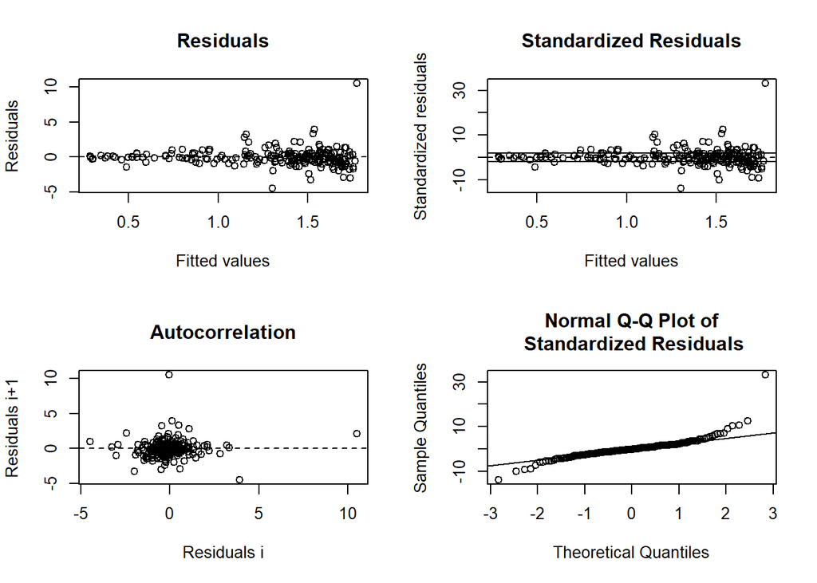

```
##
## ------
##  Shapiro-Wilk normality test
##
## data:  stdres
## W = 0.80029, p-value = 5.396e-16
##
##
## ------
```

```
##
##  Runs Test
##
## data:  as.factor(run)
## Standard Normal = -0.89306, p-value = 0.3718
## alternative hypothesis: two.sided
```

### predict and plot

```
## [1] "cannot plot data with prediction"
```

### plotting 2

## M341 - Nevada-Utah Mountains Semi-Desert - Coniferous Forest - Alpine Meadow

### model selection 1

#### summary

- simple model: does not fit
- alpha model: does not fit

### plot residuals

```
## [1] "cannot plot residuals"
```

### predict and plot

```
## [1] "cannot plot data with prediction"
```

### plotting 2

## Fitted parameters

### Best / selected models by ecoprovince

| Code | Ecoregion | Sel.Mod |
| --- | --- | --- |
| 211 | Northeastern Mixed Forest | 2 |
| 212 | Laurentian Mixed Forest | 2 |
| 221 | Eastern Broadleaf Forest | 2 |
| 222 | Midwest Broadleaf Forest | 2 |
| 223 | Central Interior Broadleaf Forest | 2 |
| 231 | Southeastern Mixed Forest | 2 |
| 232 | Outer Coastal Plain Mixed Forest | 2 |
| 234 | Lower Mississippi Riverine Forest | 2 |
| 242 | Pacific Lowland Mixed Forest | NA |
| 251 | Prairie Parkland (Temperate) | 2 |
| 255 | Prairie Parkland (Subtropical) | 2 |
| 261 | California Coastal Chaparral Forest and Shrub | NA |
| 262 | California Dry Steppe | NA |
| 263 | California Coastal Steppe - Mixed Forest and Redwood Forest | NA |
| 313 | Colorado Plateau Semi-Desert | NA |
| 315 | Southwest Plateau and Plains Dry Steppe and Shrub | NA |
| 321 | Chihuahuan Semi-Desert | NA |
| 322 | American Semidesert and Desert | NA |
| 331 | Great Plains/Palouse Dry Steppe | NA |
| 332 | Great Plains Steppe | NA |
| 341 | Intermountain Semi-Desert and Desert | NA |
| 342 | Intermountain Semi-Desert | NA |
| 411 | Everglades | NA |
| M211 | Adirondack-New England Mixed forest - Coniferous Forest - Alpine Meadow | 2 |
| M221 | Central Appalachian Broadleaf Forest - Coniferous Forest - Meadow | 2 |
| M223 | Ozark Broadleaf Forest Meadow | 2 |
| M231 | Ouachita Mixed Forest | 1 |
| M242 | Cascade Mixed Forest | NA |
| M261 | Sierran Steppe - Mixed Forest - Coniferous Forest - Alpine Meadow | 2 |
| M262 | California Coastal Range Coniferous Forest - Open Woodland - Shrub - Meadow | NA |
| M313 | Arizona-New Mexico Mountains Semi-Desert - Open Woodland - Coniferous Forest - Alpine Meadow | NA |
| M331 | Southern Rocky Mountain Steppe - Open Woodland - Coniferous Forest - Alpine Meadow | NA |
| M332 | Middle Rocky Mountain Steppe - Coniferous Forest - Alpine Meadow | NA |
| M333 | Northern Rocky Mountain Steppe - Coniferous Forest - Alpine Meadow | NA |
| M334 | Black Hills Coniferous Forest | 2 |
| M341 | Nevada-Utah Mountains Semi-Desert - Coniferous Forest - Alpine Meadow | NA |

### table by ecoprovince

| Code | Ecoregion | region | n.obs | n.plots | tau | tau.variance | tau.2.5 | tau.97.5 | alpha | alpha.variance | alpha.2.5 | alpha.97.5 | a | a.2.5 | a.97.5 | b | b.2.5 | b.97.5 | c | c.2.5 | c.97.5 | d | d.2.5 | d.97.5 |
| --- | --- | --- | --- | --- | --- | --- | --- | --- | --- | --- | --- | --- | --- | --- | --- | --- | --- | --- | --- | --- | --- | --- | --- | --- |
| 211 | Northeastern Mixed Forest | east | 4834 | 2417 | NA | NA | NA | NA | NA | NA | NA | NA | NA | NA | NA | NA | NA | NA | NA | NA | NA | NA | NA | NA |
| 212 | Laurentian Mixed Forest | east | 12976 | 6488 | NA | NA | NA | NA | NA | NA | NA | NA | NA | NA | NA | NA | NA | NA | NA | NA | NA | NA | NA | NA |
| 221 | Eastern Broadleaf Forest | east | 5462 | 2731 | NA | NA | NA | NA | NA | NA | NA | NA | NA | NA | NA | NA | NA | NA | NA | NA | NA | NA | NA | NA |
| 222 | Midwest Broadleaf Forest | east | 3554 | 1777 | NA | NA | NA | NA | NA | NA | NA | NA | NA | NA | NA | NA | NA | NA | NA | NA | NA | NA | NA | NA |
| 223 | Central Interior Broadleaf Forest | east | 6390 | 3195 | NA | NA | NA | NA | NA | NA | NA | NA | NA | NA | NA | NA | NA | NA | NA | NA | NA | NA | NA | NA |
| 231 | Southeastern Mixed Forest | east | 8200 | 4100 | NA | NA | NA | NA | NA | NA | NA | NA | NA | NA | NA | NA | NA | NA | NA | NA | NA | NA | NA | NA |
| 232 | Outer Coastal Plain Mixed Forest | east | 8194 | 4097 | NA | NA | NA | NA | NA | NA | NA | NA | NA | NA | NA | NA | NA | NA | NA | NA | NA | NA | NA | NA |
| 234 | Lower Mississippi Riverine Forest | east | 862 | 431 | NA | NA | NA | NA | NA | NA | NA | NA | NA | NA | NA | NA | NA | NA | NA | NA | NA | NA | NA | NA |
| 242 | Pacific Lowland Mixed Forest | pacific | 0 | 0 | NA | NA | NA | NA | NA | NA | NA | NA | NA | NA | NA | NA | NA | NA | NA | NA | NA | NA | NA | NA |
| 251 | Prairie Parkland (Temperate) | east | 1394 | 697 | NA | NA | NA | NA | NA | NA | NA | NA | NA | NA | NA | NA | NA | NA | NA | NA | NA | NA | NA | NA |
| 255 | Prairie Parkland (Subtropical) | east | 446 | 223 | NA | NA | NA | NA | NA | NA | NA | NA | NA | NA | NA | NA | NA | NA | NA | NA | NA | NA | NA | NA |
| 261 | California Coastal Chaparral Forest and Shrub | pacific | 0 | 0 | NA | NA | NA | NA | NA | NA | NA | NA | NA | NA | NA | NA | NA | NA | NA | NA | NA | NA | NA | NA |
| 262 | California Dry Steppe | pacific | 0 | 0 | NA | NA | NA | NA | NA | NA | NA | NA | NA | NA | NA | NA | NA | NA | NA | NA | NA | NA | NA | NA |
| 263 | California Coastal Steppe - Mixed Forest and Redwood Forest | pacific | 4 | 2 | NA | NA | NA | NA | NA | NA | NA | NA | NA | NA | NA | NA | NA | NA | NA | NA | NA | NA | NA | NA |
| 313 | Colorado Plateau Semi-Desert | interior west | 0 | 0 | NA | NA | NA | NA | NA | NA | NA | NA | NA | NA | NA | NA | NA | NA | NA | NA | NA | NA | NA | NA |
| 315 | Southwest Plateau and Plains Dry Steppe and Shrub | interior west | 0 | 0 | NA | NA | NA | NA | NA | NA | NA | NA | NA | NA | NA | NA | NA | NA | NA | NA | NA | NA | NA | NA |
| 321 | Chihuahuan Semi-Desert | interior west | 0 | 0 | NA | NA | NA | NA | NA | NA | NA | NA | NA | NA | NA | NA | NA | NA | NA | NA | NA | NA | NA | NA |
| 322 | American Semidesert and Desert | interior west | 0 | 0 | NA | NA | NA | NA | NA | NA | NA | NA | NA | NA | NA | NA | NA | NA | NA | NA | NA | NA | NA | NA |
| 331 | Great Plains/Palouse Dry Steppe | interior west | 118 | 59 | NA | NA | NA | NA | NA | NA | NA | NA | NA | NA | NA | NA | NA | NA | NA | NA | NA | NA | NA | NA |
| 332 | Great Plains Steppe | interior west | 154 | 77 | NA | NA | NA | NA | NA | NA | NA | NA | NA | NA | NA | NA | NA | NA | NA | NA | NA | NA | NA | NA |
| 341 | Intermountain Semi-Desert and Desert | interior west | 4 | 2 | NA | NA | NA | NA | NA | NA | NA | NA | NA | NA | NA | NA | NA | NA | NA | NA | NA | NA | NA | NA |
| 342 | Intermountain Semi-Desert | interior west | 2 | 1 | NA | NA | NA | NA | NA | NA | NA | NA | NA | NA | NA | NA | NA | NA | NA | NA | NA | NA | NA | NA |
| 411 | Everglades | east | 66 | 33 | NA | NA | NA | NA | NA | NA | NA | NA | NA | NA | NA | NA | NA | NA | NA | NA | NA | NA | NA | NA |
| M211 | Adirondack-New England Mixed forest - Coniferous Forest - Alpine Meadow | east | 5104 | 2552 | NA | NA | NA | NA | NA | NA | NA | NA | NA | NA | NA | NA | NA | NA | NA | NA | NA | NA | NA | NA |
| M221 | Central Appalachian Broadleaf Forest - Coniferous Forest - Meadow | east | 5262 | 2631 | NA | NA | NA | NA | NA | NA | NA | NA | NA | NA | NA | NA | NA | NA | NA | NA | NA | NA | NA | NA |
| M223 | Ozark Broadleaf Forest Meadow | east | 604 | 302 | NA | NA | NA | NA | NA | NA | NA | NA | NA | NA | NA | NA | NA | NA | NA | NA | NA | NA | NA | NA |
| M231 | Ouachita Mixed Forest | east | 678 | 339 | NA | NA | NA | NA | NA | NA | NA | NA | NA | NA | NA | NA | NA | NA | NA | NA | NA | NA | NA | NA |
| M242 | Cascade Mixed Forest | pacific | 34 | 17 | NA | NA | NA | NA | NA | NA | NA | NA | NA | NA | NA | NA | NA | NA | NA | NA | NA | NA | NA | NA |
| M261 | Sierran Steppe - Mixed Forest - Coniferous Forest - Alpine Meadow | pacific | 340 | 170 | NA | NA | NA | NA | NA | NA | NA | NA | NA | NA | NA | NA | NA | NA | NA | NA | NA | NA | NA | NA |
| M262 | California Coastal Range Coniferous Forest - Open Woodland - Shrub - Meadow | interior west | 8 | 4 | NA | NA | NA | NA | NA | NA | NA | NA | NA | NA | NA | NA | NA | NA | NA | NA | NA | NA | NA | NA |
| M313 | Arizona-New Mexico Mountains Semi-Desert - Open Woodland - Coniferous Forest - Alpine Meadow | interior west | 0 | 0 | NA | NA | NA | NA | NA | NA | NA | NA | NA | NA | NA | NA | NA | NA | NA | NA | NA | NA | NA | NA |
| M331 | Southern Rocky Mountain Steppe - Open Woodland - Coniferous Forest - Alpine Meadow | interior west | 0 | 0 | NA | NA | NA | NA | NA | NA | NA | NA | NA | NA | NA | NA | NA | NA | NA | NA | NA | NA | NA | NA |
| M332 | Middle Rocky Mountain Steppe - Coniferous Forest - Alpine Meadow | interior west | 20 | 10 | NA | NA | NA | NA | NA | NA | NA | NA | NA | NA | NA | NA | NA | NA | NA | NA | NA | NA | NA | NA |
| M333 | Northern Rocky Mountain Steppe - Coniferous Forest - Alpine Meadow | interior west | 22 | 11 | NA | NA | NA | NA | NA | NA | NA | NA | NA | NA | NA | NA | NA | NA | NA | NA | NA | NA | NA | NA |
| M334 | Black Hills Coniferous Forest | interior west | 310 | 155 | NA | NA | NA | NA | NA | NA | NA | NA | NA | NA | NA | NA | NA | NA | NA | NA | NA | NA | NA | NA |
| M341 | Nevada-Utah Mountains Semi-Desert - Coniferous Forest - Alpine Meadow | interior west | 0 | 0 | NA | NA | NA | NA | NA | NA | NA | NA | NA | NA | NA | NA | NA | NA | NA | NA | NA | NA | NA | NA |

### plot tau

[figure not shown]

#### map

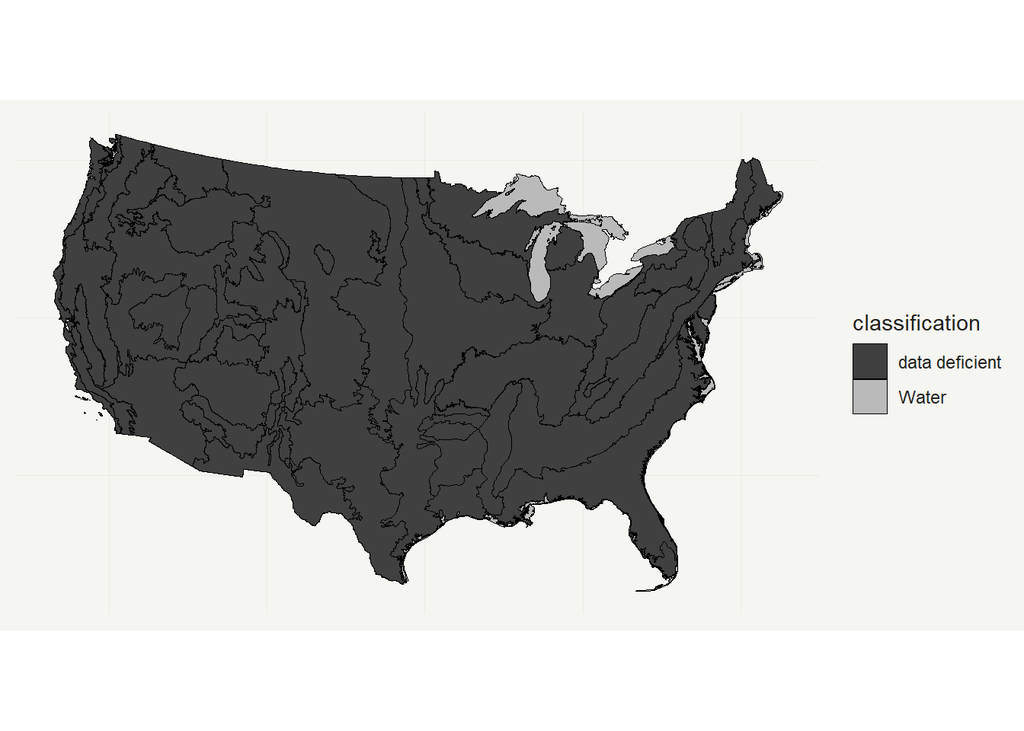

### plot alpha (biomass growth compensation effect)

[figure not shown]

### plot a coefficient

[figure not shown]

### plot b coefficient

[figure not shown]

### plot c coefficient

[figure not shown]

### plot d coefficient

[figure not shown]

## Caclulations - weighted averages

### tau (stand biomass growth enhancement factor in % 2000-2021)

```
##          region weighted.tau weighted.tau.std_Error 95 % CI, upper
## 1     entire US            0                      0              0
## 2       pacific            0                      0              0
## 3          east            0                      0              0
## 4 interior west            0                      0              0
##   95 % CI, lower
## 1              0
## 2              0
## 3              0
## 4              0
```

```
##          region weighted.phi weighted.phi.std_Error 95 % CI, upper
## 1     entire US            0                      0              0
## 2       pacific            0                      0              0
## 3          east            0                      0              0
## 4 interior west            0                      0              0
##   95 % CI, lower
## 1              0
## 2              0
## 3              0
## 4              0
```

### alpha (biomass growth compensation effect)

```
##          region weighted.alpha weighted.alpha.std_Error 95 % CI, upper
## 1     entire US              0                        0              0
## 2       pacific              0                        0              0
## 3          east              0                        0              0
## 4 interior west              0                        0              0
##   95 % CI, lower
## 1              0
## 2              0
## 3              0
## 4              0
```

# Analysis 2: Temporally-balanced, No-harvest

## 211 - Northeastern Mixed Forest

### model selection 1

```
## Analysis of Variance Table
##
## Model 1: G_MassBal_MgHaYr ~ (1 + (MEASTIME_avg - 1990) * tau/100) * (a + b * exp(-((log(STDAGE_t1/c))/d)^2))
## Model 2: G_MassBal_MgHaYr ~ (1 + (MEASTIME_avg - 1990) * tau/100) * (1 - alpha * B_L_prop) * (a + b * exp(-((log(STDAGE_t1/c))/d)^2))
##   Res.Df Res.Sum Sq Df Sum Sq F value    Pr(>F)
## 1   3752     1425.7
## 2   3720     1102.4 32 323.25  34.087 < 2.2e-16 ***
## ---
## Signif. codes:  0 '***' 0.001 '**' 0.01 '*' 0.05 '.' 0.1 ' ' 1
##   model      AIC
## 1     1 15719.00
## 2     2 14668.13
```

```
##
## Formula: G_MassBal_MgHaYr ~ (1 + (MEASTIME_avg - 1990) * tau/100) * (1 -
##     alpha * B_L_prop) * (a + b * exp(-((log(STDAGE_t1/c))/d)^2))
##
## Parameters:
##       Estimate Std. Error t value Pr(>|t|)
## tau    0.27496    0.21235   1.295    0.195
## alpha  0.71095    0.08843   8.040  1.2e-15 ***
## a      0.00000    3.82701   0.000    1.000
## b      3.40650    3.80764   0.895    0.371
## c     30.34190    2.93769  10.328  < 2e-16 ***
## d      2.90647    1.94969   1.491    0.136
## ---
## Signif. codes:  0 '***' 0.001 '**' 0.01 '*' 0.05 '.' 0.1 ' ' 1
##
## Residual standard error: 0.5444 on 3720 degrees of freedom
##
## Algorithm "port", convergence message: relative convergence (4)
##   (34 observations deleted due to missingness)
```

#### summary

- simple model: fits
- alpha model: fits

### plot residuals

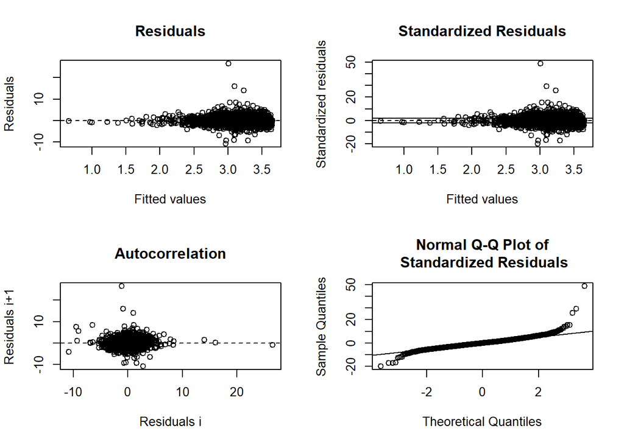

```
##
## ------
##  Shapiro-Wilk normality test
##
## data:  stdres
## W = 0.92654, p-value < 2.2e-16
##
##
## ------
```

```
##
##  Runs Test
##
## data:  as.factor(run)
## Standard Normal = -7.1953, p-value = 6.233e-13
## alternative hypothesis: two.sided
```

### predict and plot

```
## [1] "cannot plot data with prediction"
```

### plotting 2

## 212 - Laurentian Mixed Forest

### model selection 1

```
## Analysis of Variance Table
##
## Model 1: G_MassBal_MgHaYr ~ (1 + (MEASTIME_avg - 1990) * tau/100) * (a + b * exp(-((log(STDAGE_t1/c))/d)^2))
## Model 2: G_MassBal_MgHaYr ~ (1 + (MEASTIME_avg - 1990) * tau/100) * (1 - alpha * B_L_prop) * (a + b * exp(-((log(STDAGE_t1/c))/d)^2))
##   Res.Df Res.Sum Sq  Df Sum Sq F value    Pr(>F)
## 1   8121     2830.5
## 2   7865     1596.3 256 1234.1  23.751 < 2.2e-16 ***
## ---
## Signif. codes:  0 '***' 0.001 '**' 0.01 '*' 0.05 '.' 0.1 ' ' 1
##   model      AIC
## 1     1 34848.85
## 2     2 29584.72
```

```
##
## Formula: G_MassBal_MgHaYr ~ (1 + (MEASTIME_avg - 1990) * tau/100) * (1 -
##     alpha * B_L_prop) * (a + b * exp(-((log(STDAGE_t1/c))/d)^2))
##
## Parameters:
##       Estimate Std. Error t value Pr(>|t|)
## tau    1.38764    0.25266   5.492 4.10e-08 ***
## alpha  0.57642    0.05002  11.524  < 2e-16 ***
## a      0.88140    0.19549   4.509 6.62e-06 ***
## b      1.46132    0.19003   7.690 1.65e-14 ***
## c     22.15863    0.81264  27.267  < 2e-16 ***
## d      1.91664    0.20920   9.162  < 2e-16 ***
## ---
## Signif. codes:  0 '***' 0.001 '**' 0.01 '*' 0.05 '.' 0.1 ' ' 1
##
## Residual standard error: 0.4505 on 7865 degrees of freedom
##
## Algorithm "port", convergence message: relative convergence (4)
##   (2611 observations deleted due to missingness)
```

#### summary

- simple model: fits
- alpha model: fits

### plot residuals

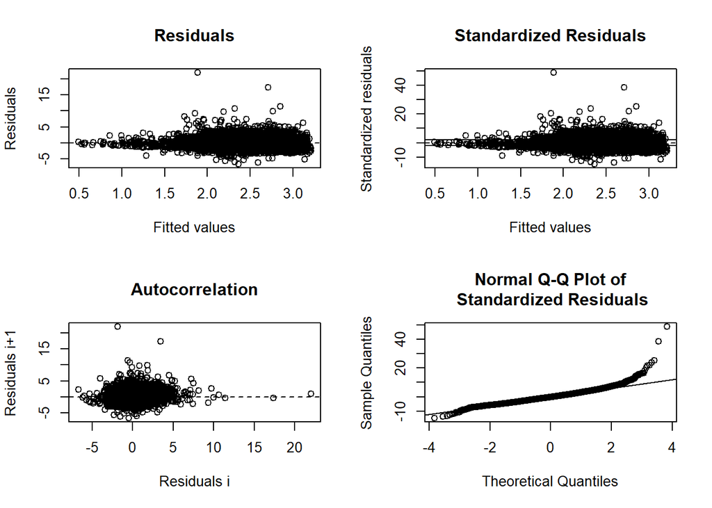

### predict and plot

```
## [1] "cannot plot data with prediction"
```

### plotting 2

## 221 - Eastern Broadleaf Forest

### model selection 1

```
## Analysis of Variance Table
##
## Model 1: G_MassBal_MgHaYr ~ (1 + (MEASTIME_avg - 1990) * tau/100) * (a + b * exp(-((log(STDAGE_t1/c))/d)^2))
## Model 2: G_MassBal_MgHaYr ~ (1 + (MEASTIME_avg - 1990) * tau/100) * (1 - alpha * B_L_prop) * (a + b * exp(-((log(STDAGE_t1/c))/d)^2))
##   Res.Df Res.Sum Sq Df Sum Sq F value    Pr(>F)
## 1   4467     1979.1
## 2   4434     1732.7 33 246.44   19.11 < 2.2e-16 ***
## ---
## Signif. codes:  0 '***' 0.001 '**' 0.01 '*' 0.05 '.' 0.1 ' ' 1
##   model      AIC
## 1     1 20675.28
## 2     2 19977.02
```

```
##
## Formula: G_MassBal_MgHaYr ~ (1 + (MEASTIME_avg - 1990) * tau/100) * (1 -
##     alpha * B_L_prop) * (a + b * exp(-((log(STDAGE_t1/c))/d)^2))
##
## Parameters:
##       Estimate Std. Error t value Pr(>|t|)
## tau   -0.53046    0.17505  -3.030  0.00246 **
## alpha  0.69098    0.08559   8.073 8.74e-16 ***
## a      0.00000    3.44224   0.000  1.00000
## b      4.49932    3.43964   1.308  0.19091
## c     35.63158    3.44884  10.331  < 2e-16 ***
## d      2.90296    1.37506   2.111  0.03482 *
## ---
## Signif. codes:  0 '***' 0.001 '**' 0.01 '*' 0.05 '.' 0.1 ' ' 1
##
## Residual standard error: 0.6251 on 4434 degrees of freedom
##
## Algorithm "port", convergence message: relative convergence (4)
##   (36 observations deleted due to missingness)
```

#### summary

- simple model: fits
- alpha model: fits

### plot residuals

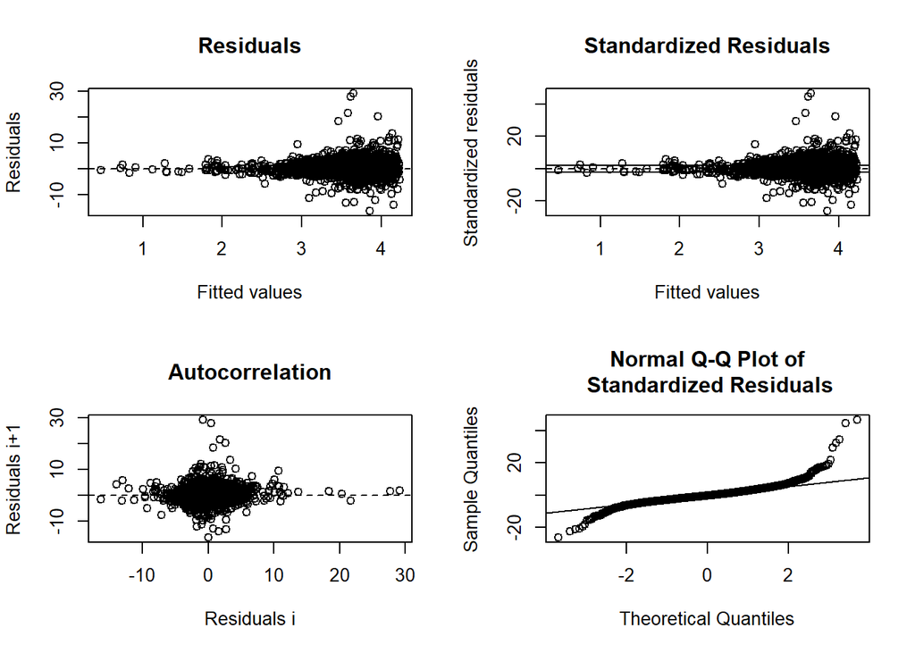

```
##
## ------
##  Shapiro-Wilk normality test
##
## data:  stdres
## W = 0.88572, p-value < 2.2e-16
##
##
## ------
```

```
##
##  Runs Test
##
## data:  as.factor(run)
## Standard Normal = -11.381, p-value < 2.2e-16
## alternative hypothesis: two.sided
```

### predict and plot

```
## [1] "cannot plot data with prediction"
```

### plotting 2

## 222 - Midwest Broadleaf Forest

### model selection 1

```
## Analysis of Variance Table
##
## Model 1: G_MassBal_MgHaYr ~ (1 + (MEASTIME_avg - 1990) * tau/100) * (a + b * exp(-((log(STDAGE_t1/c))/d)^2))
## Model 2: G_MassBal_MgHaYr ~ (1 + (MEASTIME_avg - 1990) * tau/100) * (1 - alpha * B_L_prop) * (a + b * exp(-((log(STDAGE_t1/c))/d)^2))
##   Res.Df Res.Sum Sq  Df Sum Sq F value    Pr(>F)
## 1   2250     930.63
## 2   2137     364.30 113 566.33  29.399 < 2.2e-16 ***
## ---
## Signif. codes:  0 '***' 0.001 '**' 0.01 '*' 0.05 '.' 0.1 ' ' 1
##   model       AIC
## 1     1 11488.094
## 2     2  9058.583
```

```
##
## Formula: G_MassBal_MgHaYr ~ (1 + (MEASTIME_avg - 1990) * tau/100) * (1 -
##     alpha * B_L_prop) * (a + b * exp(-((log(STDAGE_t1/c))/d)^2))
##
## Parameters:
##       Estimate Std. Error t value Pr(>|t|)
## tau    0.06337    0.32700   0.194 0.846355
## alpha  0.75649    0.08943   8.459  < 2e-16 ***
## a      1.96657    0.41983   4.684 2.99e-06 ***
## b      1.40234    0.41372   3.390 0.000713 ***
## c     48.42479    5.52341   8.767  < 2e-16 ***
## d      1.65383    0.46356   3.568 0.000368 ***
## ---
## Signif. codes:  0 '***' 0.001 '**' 0.01 '*' 0.05 '.' 0.1 ' ' 1
##
## Residual standard error: 0.4129 on 2137 degrees of freedom
##
## Algorithm "port", convergence message: relative convergence (4)
##   (655 observations deleted due to missingness)
```

#### summary

- simple model: fits
- alpha model: fits

### plot residuals

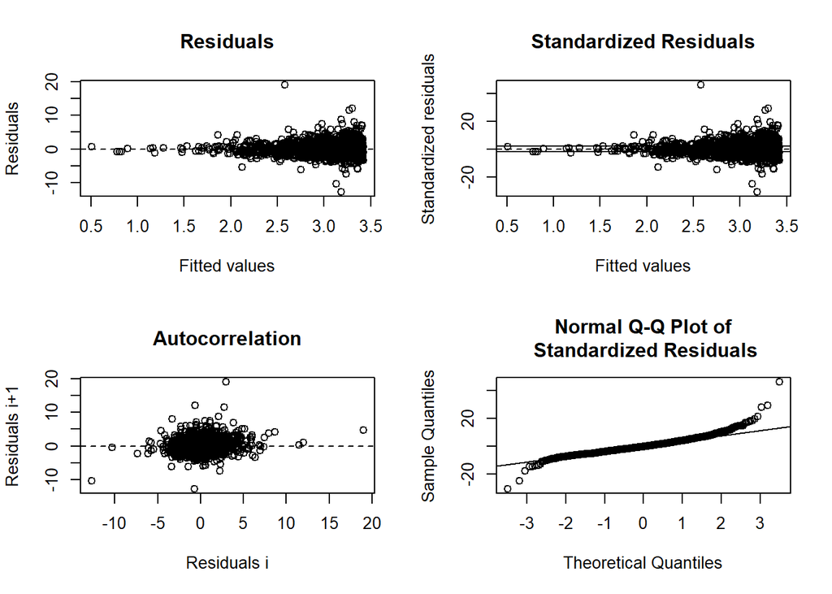

```
##
## ------
##  Shapiro-Wilk normality test
##
## data:  stdres
## W = 0.93909, p-value < 2.2e-16
##
##
## ------
```

```
##
##  Runs Test
##
## data:  as.factor(run)
## Standard Normal = -7.853, p-value = 4.063e-15
## alternative hypothesis: two.sided
```

### predict and plot

```
## [1] "cannot plot data with prediction"
```

### plotting 2

## 223 - Central Interior Broadleaf Forest

### model selection 1

```
## Analysis of Variance Table
##
## Model 1: G_MassBal_MgHaYr ~ (1 + (MEASTIME_avg - 1990) * tau/100) * (a + b * exp(-((log(STDAGE_t1/c))/d)^2))
## Model 2: G_MassBal_MgHaYr ~ (1 + (MEASTIME_avg - 1990) * tau/100) * (1 - alpha * B_L_prop) * (a + b * exp(-((log(STDAGE_t1/c))/d)^2))
##   Res.Df Res.Sum Sq Df Sum Sq F value    Pr(>F)
## 1   4350     1811.5
## 2   4268     1064.2 82 747.33  36.552 < 2.2e-16 ***
## ---
## Signif. codes:  0 '***' 0.001 '**' 0.01 '*' 0.05 '.' 0.1 ' ' 1
##   model      AIC
## 1     1 20999.77
## 2     2 18425.20
```

```
##
## Formula: G_MassBal_MgHaYr ~ (1 + (MEASTIME_avg - 1990) * tau/100) * (1 -
##     alpha * B_L_prop) * (a + b * exp(-((log(STDAGE_t1/c))/d)^2))
##
## Parameters:
##       Estimate Std. Error t value Pr(>|t|)
## tau   -0.85405    0.14573  -5.861 4.96e-09 ***
## alpha  0.50056    0.09404   5.323 1.07e-07 ***
## a      2.84506    0.51846   5.487 4.31e-08 ***
## b      1.48121    0.50011   2.962  0.00308 **
## c     30.63541    2.85080  10.746  < 2e-16 ***
## d      1.23202    0.37927   3.248  0.00117 **
## ---
## Signif. codes:  0 '***' 0.001 '**' 0.01 '*' 0.05 '.' 0.1 ' ' 1
##
## Residual standard error: 0.4993 on 4268 degrees of freedom
##
## Algorithm "port", convergence message: relative convergence (4)
##   (848 observations deleted due to missingness)
```

#### summary

- simple model: fits
- alpha model: fits

### plot residuals

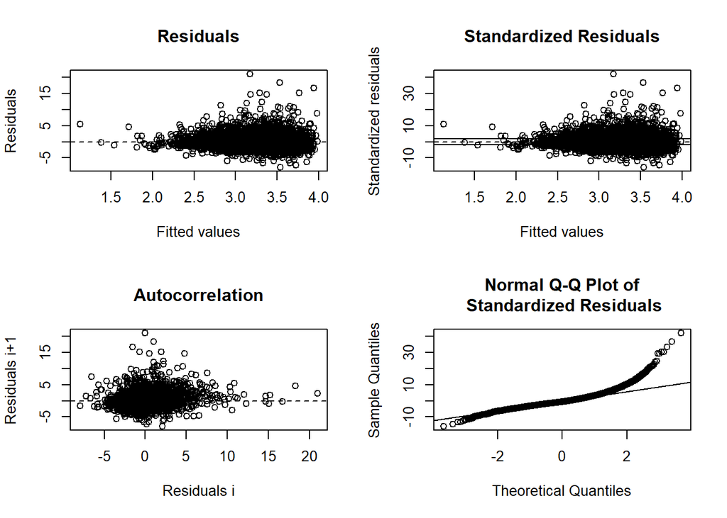

### predict and plot

```
## [1] "cannot plot data with prediction"
```

### plotting 2

## 231 - Southeastern Mixed Forest

### model selection 1

```
## Analysis of Variance Table
##
## Model 1: G_MassBal_MgHaYr ~ (1 + (MEASTIME_avg - 1990) * tau/100) * (a + b * exp(-((log(STDAGE_t1/c))/d)^2))
## Model 2: G_MassBal_MgHaYr ~ (1 + (MEASTIME_avg - 1990) * tau/100) * (1 - alpha * B_L_prop) * (a + b * exp(-((log(STDAGE_t1/c))/d)^2))
##   Res.Df Res.Sum Sq  Df Sum Sq F value    Pr(>F)
## 1   6402     3141.1
## 2   6292     2933.7 110 207.42  4.0443 < 2.2e-16 ***
## ---
## Signif. codes:  0 '***' 0.001 '**' 0.01 '*' 0.05 '.' 0.1 ' ' 1
##   model      AIC
## 1     1 33390.23
## 2     2 32584.29
```

```
##
## Formula: G_MassBal_MgHaYr ~ (1 + (MEASTIME_avg - 1990) * tau/100) * (1 -
##     alpha * B_L_prop) * (a + b * exp(-((log(STDAGE_t1/c))/d)^2))
##
## Parameters:
##       Estimate Std. Error t value Pr(>|t|)
## tau    0.75553    0.19457   3.883 0.000104 ***
## alpha  0.76757    0.07229  10.618  < 2e-16 ***
## a      1.81547    0.38798   4.679 2.94e-06 ***
## b      3.56489    0.38379   9.289  < 2e-16 ***
## c     19.53813    0.62358  31.332  < 2e-16 ***
## d      1.66938    0.16121  10.355  < 2e-16 ***
## ---
## Signif. codes:  0 '***' 0.001 '**' 0.01 '*' 0.05 '.' 0.1 ' ' 1
##
## Residual standard error: 0.6828 on 6292 degrees of freedom
##
## Algorithm "port", convergence message: relative convergence (4)
##   (146 observations deleted due to missingness)
```

#### summary

- simple model: fits
- alpha model: fits

### plot residuals

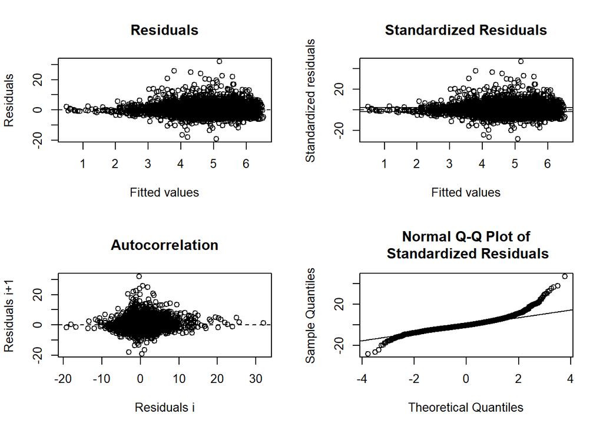

### predict and plot

```
## [1] "cannot plot data with prediction"
```

### plotting 2

## 232 - Outer Coastal Plain Mixed Forest

### model selection 1

```
## Analysis of Variance Table
##
## Model 1: G_MassBal_MgHaYr ~ (1 + (MEASTIME_avg - 1990) * tau/100) * (a + b * exp(-((log(STDAGE_t1/c))/d)^2))
## Model 2: G_MassBal_MgHaYr ~ (1 + (MEASTIME_avg - 1990) * tau/100) * (1 - alpha * B_L_prop) * (a + b * exp(-((log(STDAGE_t1/c))/d)^2))
##   Res.Df Res.Sum Sq  Df Sum Sq F value    Pr(>F)
## 1   6478     4130.0
## 2   6350     3891.5 128 238.51  3.0405 < 2.2e-16 ***
## ---
## Signif. codes:  0 '***' 0.001 '**' 0.01 '*' 0.05 '.' 0.1 ' ' 1
##   model      AIC
## 1     1 33938.10
## 2     2 33073.21
```

```
##
## Formula: G_MassBal_MgHaYr ~ (1 + (MEASTIME_avg - 1990) * tau/100) * (1 -
##     alpha * B_L_prop) * (a + b * exp(-((log(STDAGE_t1/c))/d)^2))
##
## Parameters:
##       Estimate Std. Error t value Pr(>|t|)
## tau    1.14024    0.25312   4.505 6.76e-06 ***
## alpha  0.72400    0.06100  11.869  < 2e-16 ***
## a      2.96411    0.15581  19.024  < 2e-16 ***
## b      1.91106    0.14485  13.194  < 2e-16 ***
## c     16.92057    0.75603  22.381  < 2e-16 ***
## d      0.90672    0.08526  10.635  < 2e-16 ***
## ---
## Signif. codes:  0 '***' 0.001 '**' 0.01 '*' 0.05 '.' 0.1 ' ' 1
##
## Residual standard error: 0.7828 on 6350 degrees of freedom
##
## Algorithm "port", convergence message: relative convergence (4)
##   (184 observations deleted due to missingness)
```

#### summary

- simple model: fits
- alpha model: fits

### plot residuals

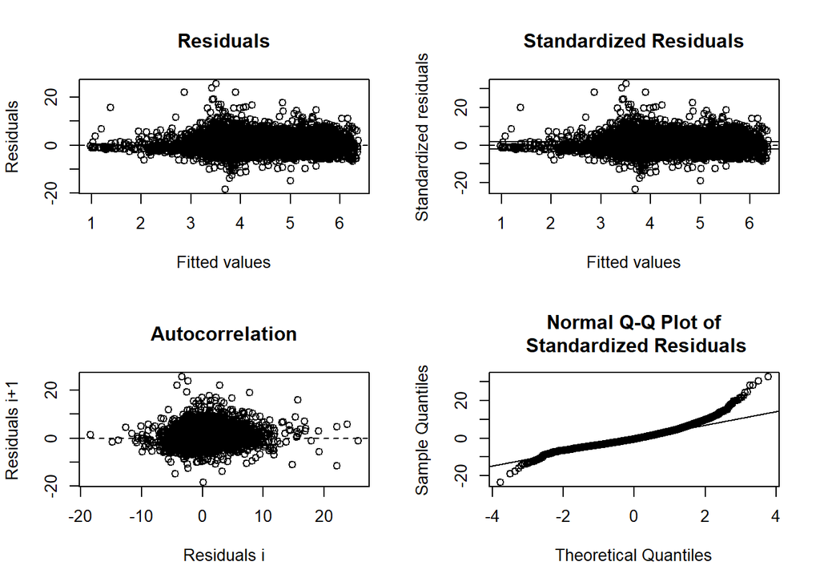

### predict and plot

```
## [1] "cannot plot data with prediction"
```

### plotting 2

## 234 - Lower Mississippi Riverine Forest

### model selection 1

```
## Analysis of Variance Table
##
## Model 1: G_MassBal_MgHaYr ~ (1 + (MEASTIME_avg - 1990) * tau/100) * (a + b * exp(-((log(STDAGE_t1/c))/d)^2))
## Model 2: G_MassBal_MgHaYr ~ (1 + (MEASTIME_avg - 1990) * tau/100) * (1 - alpha * B_L_prop) * (a + b * exp(-((log(STDAGE_t1/c))/d)^2))
##   Res.Df Res.Sum Sq Df Sum Sq F value    Pr(>F)
## 1    701     435.21
## 2    681     406.44 20 28.762  2.4096 0.0005551 ***
## ---
## Signif. codes:  0 '***' 0.001 '**' 0.01 '*' 0.05 '.' 0.1 ' ' 1
##   model      AIC
## 1     1 3724.973
## 2     2 3612.833
```

```
##
## Formula: G_MassBal_MgHaYr ~ (1 + (MEASTIME_avg - 1990) * tau/100) * (1 -
##     alpha * B_L_prop) * (a + b * exp(-((log(STDAGE_t1/c))/d)^2))
##
## Parameters:
##       Estimate Std. Error t value Pr(>|t|)
## tau     1.1094     0.9967   1.113  0.26604
## alpha   0.8163     0.1730   4.718 2.89e-06 ***
## a       3.2477     0.6339   5.123 3.91e-07 ***
## b       1.9200     0.6187   3.103  0.00199 **
## c      21.3808     3.6376   5.878 6.51e-09 ***
## d       0.7011     0.2503   2.801  0.00524 **
## ---
## Signif. codes:  0 '***' 0.001 '**' 0.01 '*' 0.05 '.' 0.1 ' ' 1
##
## Residual standard error: 0.7726 on 681 degrees of freedom
##
## Algorithm "port", convergence message: relative convergence (4)
##   (27 observations deleted due to missingness)
```

#### summary

- simple model: fits
- alpha model: fits

### plot residuals

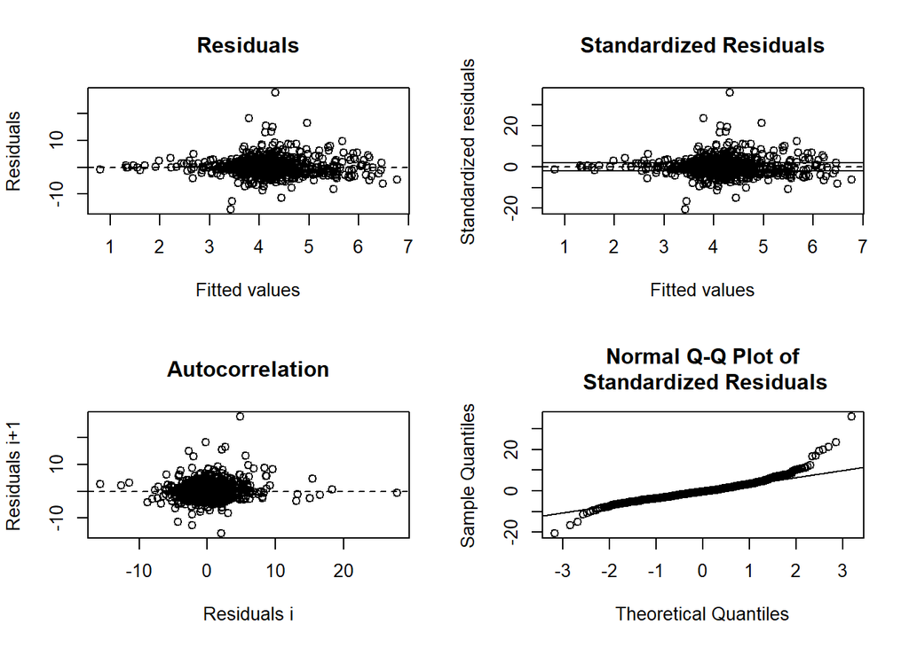

```
##
## ------
##  Shapiro-Wilk normality test
##
## data:  stdres
## W = 0.902, p-value < 2.2e-16
##
##
## ------
```

```
##
##  Runs Test
##
## data:  as.factor(run)
## Standard Normal = -2.9476, p-value = 0.003203
## alternative hypothesis: two.sided
```

### predict and plot

```
## [1] "cannot plot data with prediction"
```

### plotting 2

## 242 - Pacific Lowland Mixed Forest

### model selection 1

#### summary

- simple model: does not fit
- alpha model: does not fit

### plot residuals

```
## [1] "cannot plot residuals"
```

### predict and plot

```
## [1] "cannot plot data with prediction"
```

### plotting 2

## 251 - Prairie Parkland (Temperate)

### model selection 1

```
## Analysis of Variance Table
##
## Model 1: G_MassBal_MgHaYr ~ (1 + (MEASTIME_avg - 1990) * tau/100) * (a + b * exp(-((log(STDAGE_t1/c))/d)^2))
## Model 2: G_MassBal_MgHaYr ~ (1 + (MEASTIME_avg - 1990) * tau/100) * (1 - alpha * B_L_prop) * (a + b * exp(-((log(STDAGE_t1/c))/d)^2))
##   Res.Df Res.Sum Sq Df Sum Sq F value    Pr(>F)
## 1    924     488.51
## 2    865     182.65 59 305.87  24.552 < 2.2e-16 ***
## ---
## Signif. codes:  0 '***' 0.001 '**' 0.01 '*' 0.05 '.' 0.1 ' ' 1
##   model      AIC
## 1     1 4877.980
## 2     2 3784.144
```

```
##
## Formula: G_MassBal_MgHaYr ~ (1 + (MEASTIME_avg - 1990) * tau/100) * (1 -
##     alpha * B_L_prop) * (a + b * exp(-((log(STDAGE_t1/c))/d)^2))
##
## Parameters:
##       Estimate Std. Error t value Pr(>|t|)
## tau     0.2950     0.6708   0.440   0.6602
## alpha   0.4295     0.1898   2.263   0.0239 *
## a       0.0000   253.6503   0.000   1.0000
## b       2.8480   253.5506   0.011   0.9910
## c      11.2383    33.7072   0.333   0.7389
## d       7.8051   367.3847   0.021   0.9831
## ---
## Signif. codes:  0 '***' 0.001 '**' 0.01 '*' 0.05 '.' 0.1 ' ' 1
##
## Residual standard error: 0.4595 on 865 degrees of freedom
##
## Algorithm "port", convergence message: relative convergence (4)
##   (349 observations deleted due to missingness)
```

#### summary

- simple model: fits
- alpha model: fits

### plot residuals

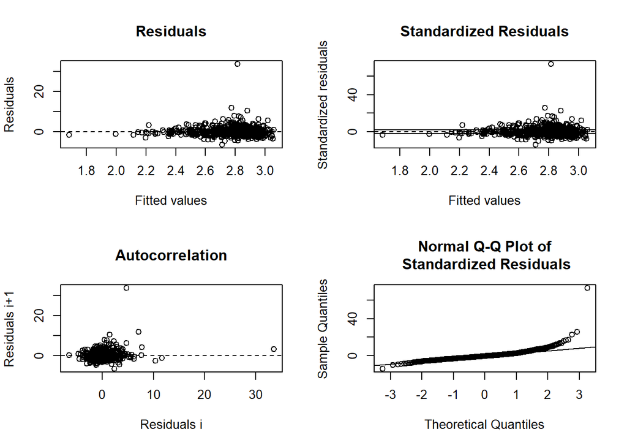

```
##
## ------
##  Shapiro-Wilk normality test
##
## data:  stdres
## W = 0.72826, p-value < 2.2e-16
##
##
## ------
```

```
##
##  Runs Test
##
## data:  as.factor(run)
## Standard Normal = -3.3062, p-value = 0.0009458
## alternative hypothesis: two.sided
```